# Final Report

### Members: Dan Shao, Weiyao(Miya) Ma, Yingjie Gao

## Table of Content

1. Background
2. Dataset Description
3. Analysis Direction & Research Objectives
   - 3.1 Rating
   - 3.2 Pricing
   - 3.3 Reviews
4. Project Progress
   - 4.1 Data Cleaning for App (googleplaystore.csv)
     - 4.1.1 Overall Dataset
     - 4.1.2 App
     - 4.1.3 Category
     - 4.1.4 Rating
     - 4.1.5 Reviews
     - 4.1.6 Size
     - 4.1.7 Installs
     - 4.1.8 Price
     - 4.1.9 Genres
     - 4.1.10 Last Updated
     - 4.1.11 Last_Updated_Days
   - 4.2 Data Cleaning for Review (googleplaystore_user_reviews.csv)
     - 4.2.1 Overall Dataset
     - 4.2.2 Translated_Review (Text Process)
   - 4.3 Feature Engineering
     - 4.3.1 Rating
     - 4.3.2 Pricing
     - 4.3.3 Review
   - 4.4 Modeling & Findings
     - 4.4.1 Modeling for Rating
     - 4.4.2 Findings from Rating
     - 4.4.3 Logistic Regression for Pricing (Free VS Paid)
     - 4.4.4 Tree for Pricing (Free VS Paid)
     - 4.4.5 Random Forest for Pricing (Free VS Paid)
     - 4.4.6 Linear Regression for Pricing
     - 4.4.7 Findings from Pricing
5. Suggestions

## 1. Background

Nowadays, apps affect all aspects of our life, such as Uber, Twitter, Yelp, etc. These apps make people's life more convenient, improve production efficiency, and provide more choices and possibilities. More importantly, they contain a lot of valuable information worth studying. By mining the information of app store, we would have a deeper understanding of this field to help app developers find business opportunities, make decisions and adjust the app in time. We can also gain some insights about people or society. After researching for this topic, we found that there have been many comprehensive analyses for iOS Apps, but conversely, analysis for Apps in Android, actually the most popular mobile operating system, is not that much, so we choose a dataset focusing on Android Apps market to study.

## 2. Data Description

Our dataset is from Kaggle dataset provided by Lavanya Gupta who scraped it from Google Play Store (https://play.google.com/store/apps) and updated last month. The data includes two csv files:

1. **googleplaystore.csv**: details about apps consist of 13 columns and 10841 rows:
   - **App**: Application name
   - **Category**: Category the app belongs to
   - **Rating**: Overall user rating of the app (as when scraped)
   - **Reviews**: Number of user reviews for the app (as when scraped)
   - **Size**: Size of the app (as when scraped)
   - **Installs**: Number of user downloads/installs for the app (as when scraped)
   - **Type**: Paid or Free
   - **Price**: Price of the app (as when scraped)
   - **Genres**: An app can belong to multiple genres (apart from its main category). e.g., a musical family game will belong to Music, Game, Family genres.
   - **Content Rating**: Age group the app is targeted at - Children / Mature 21+ / Adult
   - **Last Updated**: Date when the app was last updated on Play Store (as when scraped)
   - **Current Ver**: Current version of the app available on Play Store (as when scraped)
   - **Android Ver**: Min required Android version (as when scraped)
1. **googleplaystore_user_reviews.csv** (5 columns and 64294 rows): first ‘most relevant’ 100 reviews for each app with 3 new features: Sentiment, Sentiment Polarity and Sentiment Subjectivity:
   - **App**: Name of app
   - **Translated_Review**: User review (Preprocessed and translated to English)
   - **Sentiment**: Positive/Negative/Neutral (Preprocessed)
   - **Sentiment_Polarity**: Sentiment polarity score
   - **Sentiment_Subjectivity**: Sentiment subjectivity score

```python
import pandas as pd
import numpy as np
import matplotlib.pyplot as plt
import seaborn as sns
from scipy import stats
import statsmodels.api as sm
sns.set()
%matplotlib inline
import nltk
from collections import Counter, defaultdict
from nltk.text import Text
from nltk.tokenize import word_tokenize, sent_tokenize, regexp_tokenize
from nltk.corpus import stopwords
from nltk.stem import PorterStemmer, WordNetLemmatizer
from wordcloud import WordCloud
from gensim.corpora.dictionary import Dictionary
```

**Googleplaystore.csv Overview**

```python
# load the first csv file
app = pd.read_csv('googleplaystore.csv', header=0)
# demonstrate the first 5 row of data
app.head()
```

|  | App | Category | Rating | Reviews | Size | Installs | Type | Price | Content Rating | Genres | Last Updated | Current Ver | Android Ver |
| --- | --- | --- | --- | --- | --- | --- | --- | --- | --- | --- | --- | --- | --- |
| 0 | Photo Editor & Candy Camera & Grid & ScrapBook | ART_AND_DESIGN | 4.1 | 159 | 19M | 10,000+ | Free | 0 | Everyone | Art & Design | January 7, 2018 | 1.0.0 | 4.0.3 and up |
| 1 | Coloring book moana | ART_AND_DESIGN | 3.9 | 967 | 14M | 500,000+ | Free | 0 | Everyone | Art & Design;Pretend Play | January 15, 2018 | 2.0.0 | 4.0.3 and up |
| 2 | U Launcher Lite – FREE Live Cool Themes, Hide ... | ART_AND_DESIGN | 4.7 | 87510 | 8.7M | 5,000,000+ | Free | 0 | Everyone | Art & Design | August 1, 2018 | 1.2.4 | 4.0.3 and up |
| 3 | Sketch - Draw & Paint | ART_AND_DESIGN | 4.5 | 215644 | 25M | 50,000,000+ | Free | 0 | Teen | Art & Design | June 8, 2018 | Varies with device | 4.2 and up |
| 4 | Pixel Draw - Number Art Coloring Book | ART_AND_DESIGN | 4.3 | 967 | 2.8M | 100,000+ | Free | 0 | Everyone | Art & Design;Creativity | June 20, 2018 | 1.1 | 4.4 and up |

**Googleplaystore_user_reviews.csv Overview**

```python
# load the Second csv file
reviews = pd.read_csv('googleplaystore_user_reviews.csv', header=0)
# demonstrate the first 5 row of data
reviews.head()
```

|  | App | Translated_Review | Sentiment | Sentiment_Polarity | Sentiment_Subjectivity |
| --- | --- | --- | --- | --- | --- |
| 0 | 10 Best Foods for You | I like eat delicious food. That's I'm cooking ... | Positive | 1.00 | 0.533333 |
| 1 | 10 Best Foods for You | This help eating healthy exercise regular basis | Positive | 0.25 | 0.288462 |
| 2 | 10 Best Foods for You | NaN | NaN | NaN | NaN |
| 3 | 10 Best Foods for You | Works great especially going grocery store | Positive | 0.40 | 0.875000 |
| 4 | 10 Best Foods for You | Best idea us | Positive | 1.00 | 0.300000 |

## 3. Analysis Direction & Research Objectives

### 3.1 Rating

Why ratings and reviews are crucial for an app? The most obvious reason, why an app’s rating in mobile stores matter is that a great rating and a bunch of positive reviews impresses potential users. In fact, app store reviews and ratings can give your app an competitive edge. According to a survey by Apptentive (https://www.apptentive.com/blog/2015/05/05/app-store-ratings-reviews-guide/), 59 % of people usually or always check ratings before downloading a new app. Google also confirmed to further improve their algorithm to reward high-quality apps (https://android-developers.googleblog.com/2017/02/welcome-to-google-developer-day-at-game.html). That means strong engagement and retention metrics as well as traditional measures like high star ratings have an even stronger influence on an app’s appearance in Google Play Store than ever before.

This research aims to explore what a high-rating app should be like? or what makes a high-rating app successful on customer feedbacks? In order to dig answer for this problem, we generate the following specific questions to solve to make the whole analysis in a more structured manner:

1. Rating distribution in different categories: Whether ratings show difference in different categories? Is that difference is statistically significant, or not? Have an overview for apps' ranking as a preparation for further analysis.
2. Relationship between other variable and rating: How other app features impact on rating? What is the most influencial feature?
3. Regression of rating (or other modeling): Based on previous question, we can do linear regression as well as other model such as Random Forest to predict how a new app perform on rating in Google App Store.

### 3.2 Pricing

Pricing a product is always tough. And pricing a digital product is even tougher. Obviously, to be a financial successful app is more difficult than being a high-rating one. After doing some research on the Internet, we know that there is less than 0.01 percent of all consumer mobile apps that will become financially successful throughout 2018. Many factors preventing the majority of app ideas from becoming successful, but many of them are rooted in these three overarching problems:

- Apps are expensive. it costs a lot of money to build and maintain an app, with even basic apps costing at least 25,000 USD to start. This large monetary requirement takes some startups out of the running immediately.
- Apps are plentiful. Thousands of new apps are launched every day, driven by the high market demand for new content and functionality. But that high volume means lots of competition, which makes it harder for even “good” apps to make an impact.
- Apps are often free. Users are accustomed to getting content and functionality for free (or nearly free) in most cases, so they’re not inclined to part with their money easily. This makes it hard to monetize apps in a way that stimulates profit.

Pricing is a huge topic and very tough to summrize a good pricing strategy in mobile app industry. We expect this report could provide several insights and suggestions about pricing strategy for app developers. To achieve this objective, we plan to solve the following specific questions:

1. Free VS Paid: What is the proportion of free app? For paid apps, what is the pricing distribution for them?
2. Price distribution in different categories: For all paid apps, how about the pricing distribution in different categories?
3. Relationship between other variables and price: For all paid apps, what factor is the most influtial factor on pricing?
4. Regression of pricing (modeling): Building a model to predict whether an app should be charged or not? If yes, what might be its optimal price?

### 3.3 Reviews

As we have metioned in the 3.1, comment is also very important reference for users to decide whether they would download an app. It is crucial because the developer can see the strongest points of the app and the ones which should be improved. When an app faces a ton of competition, every little aspect can make the difference when driving the attention of potential new users. Ratings and reviews are some of the most crucial factors in user acquisition and app discoverability.

This report will dig out useful customer insights from comments in order to help app developers to recognize the strengthes, weaknesses, opportunities and threats of the apps in different categories. We list following questions to work on in this report:

1. What is the number of comments most people have, long comments or short comments?
2. High-frequency positive adjective words: What customers appreciate most for apps?
3. High-frequency negative adjective words: What customers complaint most for the apps?

## 4. Project Progress

### 4.1 Data Cleaning for App (googleplaystore.csv)

For parts 4.1 and 4.2 of this report, we will preprocess the columns in the two CSV files respectively.

Among them, the first dataset has many columns, and the data types are more diverse. Cleaning for each column includes but is not limited to: checking and processing null value, changing data type, deleting obvious errors, viewing data distribution (histogram), splitting or merging data. 4.1 will include the processing of the following columns, which will be detailed in the following 4.1.1 to 4.1.10. It also includes columns, some of which haven't yet decided what to do with them finally.

- 4.1.1 Overall Dataset
- 4.1.2 App
- 4.1.3 Category
- 4.1.4 Rating
- 4.1.5 Reviews
- 4.1.6 Size
- 4.1.7 Installs
- 4.1.8 Price
- 4.1.9 Genres
- 4.1.10 Last Updated

#### 4.1.1 Overall Dataset:

- Drop duplicate data
- Drop null (If all values are NA, drop that row or column)
- Check data type

```python
# check whether there is any duplicate data
app[app.duplicated(subset='App', keep='first')]
```

|  | App | Category | Rating | Reviews | Size | Installs | Type | Price | Content Rating | Genres | Last Updated | Current Ver | Android Ver |
| --- | --- | --- | --- | --- | --- | --- | --- | --- | --- | --- | --- | --- | --- |
| 229 | Quick PDF Scanner + OCR FREE | BUSINESS | 4.2 | 80805 | Varies with device | 5,000,000+ | Free | 0 | Everyone | Business | February 26, 2018 | Varies with device | 4.0.3 and up |
| 236 | Box | BUSINESS | 4.2 | 159872 | Varies with device | 10,000,000+ | Free | 0 | Everyone | Business | July 31, 2018 | Varies with device | Varies with device |
| 239 | Google My Business | BUSINESS | 4.4 | 70991 | Varies with device | 5,000,000+ | Free | 0 | Everyone | Business | July 24, 2018 | 2.19.0.204537701 | 4.4 and up |
| 256 | ZOOM Cloud Meetings | BUSINESS | 4.4 | 31614 | 37M | 10,000,000+ | Free | 0 | Everyone | Business | July 20, 2018 | 4.1.28165.0716 | 4.0 and up |
| 261 | join.me - Simple Meetings | BUSINESS | 4.0 | 6989 | Varies with device | 1,000,000+ | Free | 0 | Everyone | Business | July 16, 2018 | 4.3.0.508 | 4.4 and up |
| 265 | Box | BUSINESS | 4.2 | 159872 | Varies with device | 10,000,000+ | Free | 0 | Everyone | Business | July 31, 2018 | Varies with device | Varies with device |
| 266 | Zenefits | BUSINESS | 4.2 | 296 | 14M | 50,000+ | Free | 0 | Everyone | Business | June 15, 2018 | 3.2.1 | 4.1 and up |
| 267 | Google Ads | BUSINESS | 4.3 | 29313 | 20M | 5,000,000+ | Free | 0 | Everyone | Business | July 30, 2018 | 1.12.0 | 4.0.3 and up |
| 268 | Google My Business | BUSINESS | 4.4 | 70991 | Varies with device | 5,000,000+ | Free | 0 | Everyone | Business | July 24, 2018 | 2.19.0.204537701 | 4.4 and up |
| 269 | Slack | BUSINESS | 4.4 | 51507 | Varies with device | 5,000,000+ | Free | 0 | Everyone | Business | August 2, 2018 | Varies with device | Varies with device |
| 270 | FreshBooks Classic | BUSINESS | 4.1 | 1802 | 26M | 100,000+ | Free | 0 | Everyone | Business | April 18, 2018 | 1.7.14 | 4.2 and up |
| 271 | Insightly CRM | BUSINESS | 3.8 | 1383 | 51M | 100,000+ | Free | 0 | Everyone | Business | July 12, 2018 | 3.24.1 | 5.0 and up |
| 272 | QuickBooks Accounting: Invoicing & Expenses | BUSINESS | 4.3 | 23175 | 41M | 1,000,000+ | Free | 0 | Everyone | Business | July 13, 2018 | 18.7 | 4.1 and up |
| 273 | HipChat - Chat Built for Teams | BUSINESS | 3.8 | 5868 | 20M | 500,000+ | Free | 0 | Everyone | Business | July 3, 2018 | 3.19.005 | 4.1 and up |
| 274 | Xero Accounting Software | BUSINESS | 3.5 | 2111 | Varies with device | 100,000+ | Free | 0 | Everyone | Business | July 30, 2018 | Varies with device | Varies with device |
| 275 | MailChimp - Email, Marketing Automation | BUSINESS | 4.1 | 5448 | 12M | 500,000+ | Free | 0 | Everyone | Business | July 25, 2018 | 4.9.1 | 5.0 and up |
| 276 | Crew - Free Messaging and Scheduling | BUSINESS | 4.6 | 4159 | 48M | 500,000+ | Free | 0 | Everyone | Business | July 20, 2018 | 6.1.2 | 4.0.3 and up |
| 277 | Asana: organize team projects | BUSINESS | 4.3 | 20815 | 10M | 1,000,000+ | Free | 0 | Everyone | Business | July 26, 2018 | 6.4.4 | 5.0 and up |
| 278 | Google Analytics | BUSINESS | 4.5 | 78662 | 22M | 1,000,000+ | Free | 0 | Everyone | Business | February 13, 2018 | 3.7.5 | 4.4 and up |
| 279 | AdWords Express | BUSINESS | 4.1 | 7149 | 11M | 1,000,000+ | Free | 0 | Everyone | Business | July 31, 2018 | 2.6.158 | 4.0 and up |
| 280 | Accounting App - Zoho Books | BUSINESS | 4.5 | 3079 | 8.5M | 100,000+ | Free | 0 | Everyone | Business | August 2, 2018 | 5.20.7 | 4.1 and up |
| 281 | Invoice & Time Tracking - Zoho | BUSINESS | 4.6 | 5800 | 8.6M | 100,000+ | Free | 0 | Everyone | Business | August 2, 2018 | 5.20.7 | 4.1 and up |
| 282 | join.me - Simple Meetings | BUSINESS | 4.0 | 6989 | Varies with device | 1,000,000+ | Free | 0 | Everyone | Business | July 16, 2018 | 4.3.0.508 | 4.4 and up |
| 283 | Invoice 2go — Professional Invoices and Estimates | BUSINESS | 4.2 | 16422 | 28M | 1,000,000+ | Free | 0 | Everyone | Business | August 1, 2018 | 10.46.2 | 4.1 and up |
| 284 | SignEasy \| Sign and Fill PDF and other Documents | BUSINESS | 4.3 | 8978 | Varies with device | 1,000,000+ | Free | 0 | Everyone | Business | July 25, 2018 | Varies with device | Varies with device |
| 285 | Quick PDF Scanner + OCR FREE | BUSINESS | 4.2 | 80804 | Varies with device | 5,000,000+ | Free | 0 | Everyone | Business | February 26, 2018 | Varies with device | 4.0.3 and up |
| 286 | Genius Scan - PDF Scanner | BUSINESS | 4.4 | 42492 | Varies with device | 1,000,000+ | Free | 0 | Everyone | Business | July 11, 2018 | Varies with device | Varies with device |
| 287 | Tiny Scanner - PDF Scanner App | BUSINESS | 4.7 | 286897 | 39M | 10,000,000+ | Free | 0 | Everyone | Business | May 30, 2017 | 1.2.6 | 3.0 and up |
| 288 | Fast Scanner : Free PDF Scan | BUSINESS | 4.5 | 103755 | 14M | 10,000,000+ | Free | 0 | Everyone | Business | July 11, 2018 | 3.9.2 | 4.1 and up |
| 289 | Mobile Doc Scanner (MDScan) Lite | BUSINESS | 4.2 | 46505 | 19M | 1,000,000+ | Free | 0 | Everyone | Business | August 2, 2018 | 3.4.49 | 4.1 and up |
| ... | ... | ... | ... | ... | ... | ... | ... | ... | ... | ... | ... | ... | ... |
| 9854 | Nike Training Club - Workouts & Fitness Plans | HEALTH_AND_FITNESS | 4.6 | 251618 | 93M | 10,000,000+ | Free | 0 | Everyone | Health & Fitness | July 18, 2018 | 5.14.0 | 5.0 and up |
| 9856 | Hangouts Dialer - Call Phones | COMMUNICATION | 4.0 | 122512 | 79k | 10,000,000+ | Free | 0 | Everyone | Communication | September 2, 2015 | 0.1.100944346 | 4.0.3 and up |
| 9859 | Offline Maps & Navigation | TRAVEL_AND_LOCAL | 4.7 | 193364 | 33M | 5,000,000+ | Free | 0 | Everyone | Travel & Local | June 7, 2018 | 17.4.1 | 4.0.3 and up |
| 9936 | Strawberry Shortcake Ice Cream Island | FAMILY | 4.2 | 32200 | 15M | 5,000,000+ | Free | 0 | Everyone | Casual;Pretend Play | November 6, 2017 | 1.2 | 4.1 and up |
| 9975 | Home Workout - No Equipment | HEALTH_AND_FITNESS | 4.8 | 432160 | 15M | 10,000,000+ | Free | 0 | Everyone | Health & Fitness | June 28, 2018 | Varies with device | Varies with device |
| 9982 | Home Security Camera WardenCam - reuse old phones | HOUSE_AND_HOME | 4.3 | 43847 | Varies with device | 1,000,000+ | Free | 0 | Everyone | House & Home | July 6, 2018 | Varies with device | Varies with device |
| 10018 | Food Network | FAMILY | 4.1 | 7823 | Varies with device | 500,000+ | Free | 0 | Teen | Entertainment | July 27, 2018 | Varies with device | Varies with device |
| 10026 | Web Browser for Android | COMMUNICATION | 4.1 | 55110 | 4.3M | 1,000,000+ | Free | 0 | Everyone | Communication | June 20, 2018 | 2.2 | 4.0 and up |
| 10049 | Airway Ex - Intubate. Anesthetize. Train. | MEDICAL | 4.3 | 123 | 86M | 10,000+ | Free | 0 | Everyone | Medical | June 1, 2018 | 0.6.88 | 5.0 and up |
| 10118 | FilterGrid - Cam&Photo Editor | PHOTOGRAPHY | 4.6 | 126338 | 9.6M | 1,000,000+ | Free | 0 | Everyone | Photography | March 15, 2017 | 2.0.5 | 4.0 and up |
| 10170 | Messages, Text and Video Chat for Messenger | SOCIAL | 4.4 | 49580 | 4.0M | 10,000,000+ | Free | 0 | Everyone | Social | June 4, 2018 | 1.24 | 4.1 and up |
| 10171 | All Social Networks | SOCIAL | 4.2 | 22650 | 1.5M | 1,000,000+ | Free | 0 | Everyone | Social | May 21, 2018 | 2.4.12 | 4.0 and up |
| 10178 | Premier League - Official App | SPORTS | 4.3 | 63782 | 24M | 5,000,000+ | Free | 0 | Everyone | Sports | August 7, 2018 | 1.1.5 | 4.1 and up |
| 10186 | Farm Heroes Saga | FAMILY | 4.4 | 7615646 | 71M | 100,000,000+ | Free | 0 | Everyone | Casual | August 7, 2018 | 5.2.6 | 2.3 and up |
| 10188 | ESPN Fantasy Sports | SPORTS | 4.0 | 176487 | 10M | 5,000,000+ | Free | 0 | Everyone | Sports | November 21, 2017 | 5.3.0 | 4.4 and up |
| 10190 | Fallout Shelter | FAMILY | 4.6 | 2721923 | 25M | 10,000,000+ | Free | 0 | Teen | Simulation | June 11, 2018 | 1.13.12 | 4.1 and up |
| 10200 | Facebook Pages Manager | BUSINESS | 4.0 | 1279800 | Varies with device | 50,000,000+ | Free | 0 | Everyone | Business | August 6, 2018 | Varies with device | Varies with device |
| 10203 | Facebook Ads Manager | BUSINESS | 4.1 | 19051 | Varies with device | 1,000,000+ | Free | 0 | Everyone | Business | August 1, 2018 | 99.0.0.35.75 | 4.1 and up |
| 10213 | Who Viewed My Facebook Profile - Stalkers Visi... | SOCIAL | 4.6 | 273244 | 9.9M | 5,000,000+ | Free | 0 | Everyone | Social | June 24, 2018 | 4.1.1 | 4.0.3 and up |
| 10269 | The 5th Stand | SPORTS | 4.8 | 1697 | 17M | 100,000+ | Free | 0 | Everyone | Sports | July 31, 2018 | 1.2.677 | 4.4 and up |
| 10327 | Garena Free Fire | GAME | 4.5 | 5534114 | 53M | 100,000,000+ | Free | 0 | Teen | Action | August 3, 2018 | 1.21.0 | 4.0.3 and up |
| 10473 | osmino Wi-Fi: free WiFi | TOOLS | 4.2 | 134203 | 4.1M | 10,000,000+ | Free | 0 | Everyone | Tools | August 7, 2018 | 6.06.14 | 4.4 and up |
| 10502 | Fun Kid Racing - Motocross | FAMILY | 4.1 | 59768 | Varies with device | 10,000,000+ | Free | 0 | Everyone | Racing;Action & Adventure | August 7, 2018 | 3.53 | 4.2 and up |
| 10646 | Podcast App: Free & Offline Podcasts by Player FM | NEWS_AND_MAGAZINES | 4.6 | 66407 | 19M | 1,000,000+ | Free | 0 | Teen | News & Magazines | July 25, 2018 | 4.1.0.72 | 4.0 and up |
| 10647 | Motorola FM Radio | VIDEO_PLAYERS | 3.9 | 54815 | Varies with device | 100,000,000+ | Free | 0 | Everyone | Video Players & Editors | May 2, 2018 | Varies with device | Varies with device |
| 10715 | FarmersOnly Dating | DATING | 3.0 | 1145 | 1.4M | 100,000+ | Free | 0 | Mature 17+ | Dating | February 25, 2016 | 2.2 | 4.0 and up |
| 10720 | Firefox Focus: The privacy browser | COMMUNICATION | 4.4 | 36981 | 4.0M | 1,000,000+ | Free | 0 | Everyone | Communication | July 6, 2018 | 5.2 | 5.0 and up |
| 10730 | FP Notebook | MEDICAL | 4.5 | 410 | 60M | 50,000+ | Free | 0 | Everyone | Medical | March 24, 2018 | 2.1.0.372 | 4.4 and up |
| 10753 | Slickdeals: Coupons & Shopping | SHOPPING | 4.5 | 33599 | 12M | 1,000,000+ | Free | 0 | Everyone | Shopping | July 30, 2018 | 3.9 | 4.4 and up |
| 10768 | AAFP | MEDICAL | 3.8 | 63 | 24M | 10,000+ | Free | 0 | Everyone | Medical | June 22, 2018 | 2.3.1 | 5.0 and up |

1181 rows × 13 columns

```python
# drop all duplicated data in googleplaystore.csv dataframe
app.drop_duplicates(keep='first', subset='App', inplace=True)
```

```python
# drop rows that only have null values
app.dropna(axis=0,how='all',inplace=True)
```

```python
print('After dropped, there are {} rows of data remained'.format(len(app)))
```

```
After dropped, there are 9660 rows of data remained
```

```python
# check data type for first dataset
app.dtypes
```

```
App                object
Category           object
Rating            float64
Reviews            object
Size               object
Installs           object
Type               object
Price              object
Content Rating     object
Genres             object
Last Updated       object
Current Ver        object
Android Ver        object
dtype: object
```

Columns required to convert type:

- change Reviews to integer
- change Size to float
- change Installs to integer
- change Price to float
- change Content Rating to float
- change Last Updated to date
- change Current Ver to float
- change Android Ver to float

#### 4.1.2 App

- Check null in app name

```python
print("{} null values out of {}".format((app.App.isna().sum()),len(app.App)))
```

```
0 null values out of 9660
```

#### 4.1.3 Category

- Eliminate abnormal value

```python
app.Category.unique()
```

```
array(['ART_AND_DESIGN', 'AUTO_AND_VEHICLES', 'BEAUTY',
       'BOOKS_AND_REFERENCE', 'BUSINESS', 'COMICS', 'COMMUNICATION',
       'DATING', 'EDUCATION', 'ENTERTAINMENT', 'EVENTS', 'FINANCE',
       'FOOD_AND_DRINK', 'HEALTH_AND_FITNESS', 'HOUSE_AND_HOME',
       'LIBRARIES_AND_DEMO', 'LIFESTYLE', 'GAME', 'FAMILY', 'MEDICAL',
       'SOCIAL', 'SHOPPING', 'PHOTOGRAPHY', 'SPORTS', 'TRAVEL_AND_LOCAL',
       'TOOLS', 'PERSONALIZATION', 'PRODUCTIVITY', 'PARENTING', 'WEATHER',
       'VIDEO_PLAYERS', 'NEWS_AND_MAGAZINES', 'MAPS_AND_NAVIGATION',
       '1.9'], dtype=object)
```

'1.9' is abnormal in category. Let's see what happend on this weird category.

```python
app[app['Category']=='1.9']
```

|  | App | Category | Rating | Reviews | Size | Installs | Type | Price | Content Rating | Genres | Last Updated | Current Ver | Android Ver |
| --- | --- | --- | --- | --- | --- | --- | --- | --- | --- | --- | --- | --- | --- |
| 10472 | Life Made WI-Fi Touchscreen Photo Frame | 1.9 | 19.0 | 3.0M | 1,000+ | Free | 0 | Everyone | NaN | February 11, 2018 | 1.0.19 | 4.0 and up | NaN |

It can be noticed that the entries are entered wrong (i.e. cell backwared). To simplify the clean process, we just delete this entry.

```python
# drop the abnormal row
app.drop(10472,axis=0,inplace=True)
```

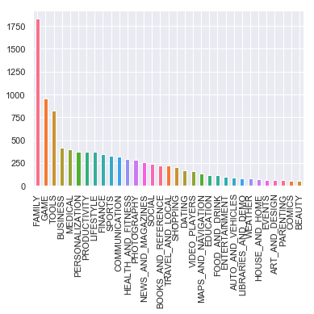

```python
app.Category.value_counts().plot(kind='bar', color=sns.color_palette("husl", 15))
```

Family has the largest number of apps, followed by game and tool. Beauty has the least quantity.

#### 4.1.4 Rating

- Make sure all ratings in range 1 to 5
- Drop null if any

```python
print("Range:{}-{}".format(app.Rating.min(),app.Rating.max()))
```

```
Range:1.0-5.0
```

```python
# Check null value
print("{} null values out of {}".format((app.Rating.isna().sum()),len(app.Rating)))
```

```
1463 null values out of 9659
```

Because Rating will be our dependent varaible in modeling, we drop those NA rows to avoid the impact of filling.

```python
# drop null values
app.dropna(subset=['Rating'],inplace=True)
print("{} null values out of {}".format((app.Rating.isna().sum()),len(app)))
```

```
0 null values out of 8196
```

```python
app.Rating.describe()
```

```
count    8196.000000
mean        4.173243
std         0.536625
min         1.000000
25%         4.000000
50%         4.300000
75%         4.500000
max         5.000000
Name: Rating, dtype: float64
```

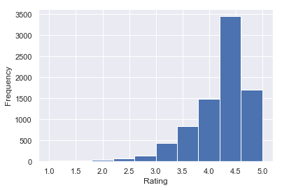

```python
# Column 'Rating' overview
app.Rating.hist(bins=10);
plt.xlabel('Rating')
plt.ylabel('Frequency')
```

Summary for Rating: Most of apps are over 4 points, and the average rating is 4.17.

#### 4.1.5 Reviews

- Drop null if any
- Change data type from boject to integer

```python
# check null
print("{} null values out of {}".format((app.Reviews.isna().sum()),len(app.Reviews)))
```

```
0 null values out of 8196
```

```python
# convert data type to float
app['Reviews'] = app['Reviews'].astype(float)
app.Reviews.describe()
```

```
count    8.196000e+03
mean     2.552515e+05
std      1.985594e+06
min      1.000000e+00
25%      1.260000e+02
50%      3.004000e+03
75%      4.381300e+04
max      7.815831e+07
Name: Reviews, dtype: float64
```

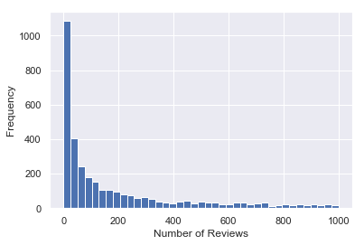

```python
bins = np.linspace(0, 1000, 40)
plt.hist(app.Reviews,bins)
plt.xlabel('Number of Reviews')
plt.ylabel('Frequency')
```

#### 4.1.6 Size

- Check null
- Replacing k and M with their values to convert values to numeric
- Replacing 'Varies with device' by 0
- Converting 1,000+ to 1000
- Change data type to float

```python
#check null
print("{} null values out of {}".format((app.Size.isna().sum()), len(app.Size)))
```

```
0 null values out of 8196
```

```python
# column overview
print(app['Size'].value_counts().head(3),app['Size'].value_counts().tail(3))
```

```
Varies with device    1169
14M                    149
12M                    146
Name: Size, dtype: int64 696k    1
309k    1
161k    1
Name: Size, dtype: int64
```

It can be seen that data has metric prefixes (Kilo and Mega) along with another string.

```python
# Replacing k and M with their values to convert values to numeric
app.Size=app.Size.str.replace('k','e+3')
app.Size=app.Size.str.replace('M','e+6')
app.Size.head()
```

```
0     19e+6
1     14e+6
2    8.7e+6
3     25e+6
4    2.8e+6
Name: Size, dtype: object
```

Now, we have some two types of values in our Size data.

1. Exponential values (not yet converted to string)
2. Strings (that cannot be converted into numeric)

Thus specifing categories 1 and 2 as an boolean array "numeric", to convert category 1 to numeric.

```python
def is_convertable(data):
    try:
        float(data)
        return True
    except ValueError:
        return False

numeric=app.Size.apply(lambda x: is_convertable(x))
numeric.head()
```

```
0    True
1    True
2    True
3    True
4    True
Name: Size, dtype: bool
```

```python
# Now checking unique non numeric values (~numeric) in Size.
app.Size[~numeric].value_counts()
```

```
Varies with device    1169
Name: Size, dtype: int64
```

```python
# Replacing 'Varies with device' by nan
app.Size=app.Size.replace('Varies with device',0)
# Converting 1,000+ to 1000
app.Size=app.Size.replace('1,000+',1000)
```

```python
# Converting the cleaned Size data to numeric type
app.Size=pd.to_numeric(app.Size)
```

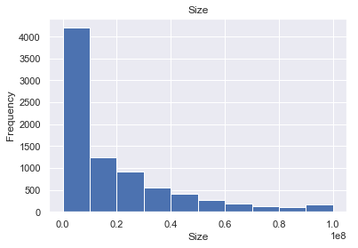

```python
# Column 'Size' overview
app.hist(column='Size')
plt.xlabel('Size')
plt.ylabel('Frequency')
```

Summary for Size: The largest app size is between 90-100M and most apps are less than 20M.

#### 4.1.7 Installs

- Drop "+" and ","
- Change 'Installs' into numeric type

```python
app.Installs.value_counts().head()
```

```
1,000,000+     1415
100,000+       1094
10,000+         987
10,000,000+     937
1,000+          697
Name: Installs, dtype: int64
```

```python
# drop "+" and ","
app.Installs=app.Installs.apply(lambda x: x.strip('+'))
app.Installs=app.Installs.apply(lambda x: x.replace(',',''))
```

```python
# change 'Installs' into numeric type
app.Installs=pd.to_numeric(app.Installs)
```

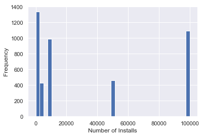

```python
bins = np.linspace(0, 100000, 40)
plt.hist(app.Installs,bins)
plt.xlabel('Number of Installs')
plt.ylabel('Frequency')
```

Summary for Installs: We can see from the chart that the distribution is very polarized that many apps have small amount of installs and a few apps are quite successful on popularization.

#### 4.1.8 Price

- Delete dollar sign
- Convert Price into float type

```python
#Check unique values for Price and have an overview for this column
app.Price.unique()
```

```
array(['0', '$4.99', '$3.99', '$6.99', '$7.99', '$5.99', '$2.99', '$3.49',
       '$1.99', '$9.99', '$7.49', '$0.99', '$9.00', '$5.49', '$10.00',
       '$24.99', '$11.99', '$79.99', '$16.99', '$14.99', '$29.99',
       '$12.99', '$2.49', '$10.99', '$1.50', '$19.99', '$15.99', '$33.99',
       '$39.99', '$3.95', '$4.49', '$1.70', '$8.99', '$1.49', '$3.88',
       '$399.99', '$17.99', '$400.00', '$3.02', '$1.76', '$4.84', '$4.77',
       '$1.61', '$2.50', '$1.59', '$6.49', '$1.29', '$299.99', '$379.99',
       '$37.99', '$18.99', '$389.99', '$8.49', '$1.75', '$14.00', '$2.00',
       '$3.08', '$2.59', '$19.40', '$3.90', '$4.59', '$15.46', '$3.04',
       '$13.99', '$4.29', '$3.28', '$4.60', '$1.00', '$2.95', '$2.90',
       '$1.97', '$2.56', '$1.20'], dtype=object)
```

```python
# Delete dollar sign
app.Price=app.Price.apply(lambda x: x.strip('$'))
# Convert Price into float type
app.Price=pd.to_numeric(app.Price)
app.Price.unique()
```

```
array([  0.  ,   4.99,   3.99,   6.99,   7.99,   5.99,   2.99,   3.49,
         1.99,   9.99,   7.49,   0.99,   9.  ,   5.49,  10.  ,  24.99,
        11.99,  79.99,  16.99,  14.99,  29.99,  12.99,   2.49,  10.99,
         1.5 ,  19.99,  15.99,  33.99,  39.99,   3.95,   4.49,   1.7 ,
         8.99,   1.49,   3.88, 399.99,  17.99, 400.  ,   3.02,   1.76,
         4.84,   4.77,   1.61,   2.5 ,   1.59,   6.49,   1.29, 299.99,
       379.99,  37.99,  18.99, 389.99,   8.49,   1.75,  14.  ,   2.  ,
         3.08,   2.59,  19.4 ,   3.9 ,   4.59,  15.46,   3.04,  13.99,
         4.29,   3.28,   4.6 ,   1.  ,   2.95,   2.9 ,   1.97,   2.56,
         1.2 ])
```

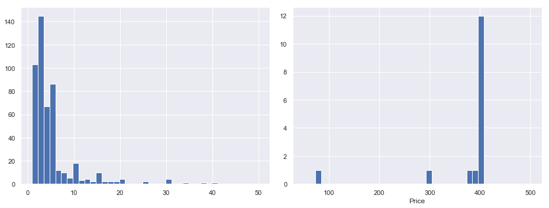

```python
# Column 'Price' overview
fig, axs = plt.subplots(1,2, sharey=False,figsize=(13, 5))
axs[0].hist(app.Price, bins=np.linspace(1, 50, 40))
axs[1].hist(app.Price, bins=np.linspace(50, 500, 40))
plt.xlabel('Price')
plt.tight_layout()
```

It is abnormal that there are some super expensive apps whose prices are **over $350!** And I checked some of them in the Google Play Store, it was surprised me that they are indeed existing...! So we will just keep them in our dataset.

[figure not shown]

```python
app[app['Price']>350]
```

|  | App | Category | Rating | Reviews | Size | Installs | Type | Price | Content Rating | Genres | Last Updated | Current Ver | Android Ver |
| --- | --- | --- | --- | --- | --- | --- | --- | --- | --- | --- | --- | --- | --- |
| 4197 | most expensive app (H) | FAMILY | 4.3 | 6.0 | 1500000.0 | 100 | Paid | 399.99 | Everyone | Entertainment | July 16, 2018 | 1.0 | 7.0 and up |
| 4362 | 💎 I'm rich | LIFESTYLE | 3.8 | 718.0 | 26000000.0 | 10000 | Paid | 399.99 | Everyone | Lifestyle | March 11, 2018 | 1.0.0 | 4.4 and up |
| 4367 | I'm Rich - Trump Edition | LIFESTYLE | 3.6 | 275.0 | 7300000.0 | 10000 | Paid | 400.00 | Everyone | Lifestyle | May 3, 2018 | 1.0.1 | 4.1 and up |
| 5351 | I am rich | LIFESTYLE | 3.8 | 3547.0 | 1800000.0 | 100000 | Paid | 399.99 | Everyone | Lifestyle | January 12, 2018 | 2.0 | 4.0.3 and up |
| 5354 | I am Rich Plus | FAMILY | 4.0 | 856.0 | 8700000.0 | 10000 | Paid | 399.99 | Everyone | Entertainment | May 19, 2018 | 3.0 | 4.4 and up |
| 5356 | I Am Rich Premium | FINANCE | 4.1 | 1867.0 | 4700000.0 | 50000 | Paid | 399.99 | Everyone | Finance | November 12, 2017 | 1.6 | 4.0 and up |
| 5357 | I am extremely Rich | LIFESTYLE | 2.9 | 41.0 | 2900000.0 | 1000 | Paid | 379.99 | Everyone | Lifestyle | July 1, 2018 | 1.0 | 4.0 and up |
| 5358 | I am Rich! | FINANCE | 3.8 | 93.0 | 22000000.0 | 1000 | Paid | 399.99 | Everyone | Finance | December 11, 2017 | 1.0 | 4.1 and up |
| 5359 | I am rich(premium) | FINANCE | 3.5 | 472.0 | 965000.0 | 5000 | Paid | 399.99 | Everyone | Finance | May 1, 2017 | 3.4 | 4.4 and up |
| 5362 | I Am Rich Pro | FAMILY | 4.4 | 201.0 | 2700000.0 | 5000 | Paid | 399.99 | Everyone | Entertainment | May 30, 2017 | 1.54 | 1.6 and up |
| 5364 | I am rich (Most expensive app) | FINANCE | 4.1 | 129.0 | 2700000.0 | 1000 | Paid | 399.99 | Teen | Finance | December 6, 2017 | 2 | 4.0.3 and up |
| 5366 | I Am Rich | FAMILY | 3.6 | 217.0 | 4900000.0 | 10000 | Paid | 389.99 | Everyone | Entertainment | June 22, 2018 | 1.5 | 4.2 and up |
| 5369 | I am Rich | FINANCE | 4.3 | 180.0 | 3800000.0 | 5000 | Paid | 399.99 | Everyone | Finance | March 22, 2018 | 1.0 | 4.2 and up |
| 5373 | I AM RICH PRO PLUS | FINANCE | 4.0 | 36.0 | 41000000.0 | 1000 | Paid | 399.99 | Everyone | Finance | June 25, 2018 | 1.0.2 | 4.1 and up |

Summary for Price: Most of apps are charged under 20 USD, but some apps are extremely expensive, which attract a lot of conspicuous consumptions.

#### 4.1.9 Genres

- Checking for unique values, abnormalitity and repetition
- Divide the data into two columns

```python
app.Genres.unique()[:30]
```

```
array(['Art & Design', 'Art & Design;Pretend Play',
       'Art & Design;Creativity', 'Auto & Vehicles', 'Beauty',
       'Books & Reference', 'Business', 'Comics', 'Comics;Creativity',
       'Communication', 'Dating', 'Education;Education', 'Education',
       'Education;Creativity', 'Education;Music & Video',
       'Education;Action & Adventure', 'Education;Pretend Play',
       'Education;Brain Games', 'Entertainment',
       'Entertainment;Music & Video', 'Entertainment;Brain Games',
       'Entertainment;Creativity', 'Events', 'Finance', 'Food & Drink',
       'Health & Fitness', 'House & Home', 'Libraries & Demo',
       'Lifestyle', 'Lifestyle;Pretend Play'], dtype=object)
```

The data is in the format 'Category;Subcategory'. Lets divide the data into two columns, one as primary category and the other as secondary, using ; as separator.

```python
# split and create a new column for primary category
rest = app.Genres.apply(lambda x: x.split(';')[0])
app['Pri_Genres']=rest
app.Pri_Genres.head()
```

```
0    Art & Design
1    Art & Design
2    Art & Design
3    Art & Design
4    Art & Design
Name: Pri_Genres, dtype: object
```

```python
# create another new column for second category
rest = app.Genres.apply(lambda x: x.split(';')[-1])
rest.unique()
app['Sec_Genres']=rest
app.Sec_Genres.head()
```

```
0    Art & Design
1    Pretend Play
2    Art & Design
3    Art & Design
4      Creativity
Name: Sec_Genres, dtype: object
```

```python
# have a quick look for the primary and second categories
grouped = app.groupby(['Pri_Genres','Sec_Genres'])
grouped.size()
```

```
Pri_Genres               Sec_Genres
Action                   Action                     292
                         Action & Adventure          12
Adventure                Action & Adventure           5
                         Adventure                   71
                         Brain Games                  1
                         Education                    1
Arcade                   Action & Adventure          13
                         Arcade                     171
                         Pretend Play                 1
Art & Design             Art & Design                55
                         Creativity                   6
                         Pretend Play                 1
Auto & Vehicles          Auto & Vehicles             73
Beauty                   Beauty                      42
Board                    Action & Adventure           3
                         Board                       38
                         Brain Games                 15
                         Pretend Play                 1
Books & Reference        Books & Reference          169
                         Education                    2
Business                 Business                   263
Card                     Action & Adventure           2
                         Card                        44
Casino                   Casino                      37
Casual                   Action & Adventure          13
                         Brain Games                 12
                         Casual                     157
                         Creativity                   6
                         Education                    3
                         Music & Video                1
                                                   ...
Puzzle                   Puzzle                     100
Racing                   Action & Adventure          16
                         Pretend Play                 1
                         Racing                      86
Role Playing             Action & Adventure           4
                         Brain Games                  1
                         Pretend Play                 4
                         Role Playing               102
```

[output cut: 8 more lines]

```
Strategy                 Action & Adventure           2
                         Creativity                   1
                         Education                    1
                         Strategy                    91
Tools                    Education                    1
                         Tools                      717
Travel & Local           Action & Adventure           1
                         Travel & Local             186
Trivia                   Trivia                      28
Video Players & Editors  Creativity                   1
                         Music & Video                2
                         Video Players & Editors    147
Weather                  Weather                     72
Word                     Word                        22
Length: 113, dtype: int64
```

To better understand these two categories, we generate a table:

```python
table_cate = pd.crosstab(index=app["Pri_Genres"],columns=app["Sec_Genres"])
# add a new column to count total number of apps for each primary genres
table_cate['Total']=table_cate.sum(axis=1)
table_cate.head(10)
```

| Sec_Genres Pri_Genres | Action | Action & Adventure | Adventure | Arcade | Art & Design | Auto & Vehicles | Beauty | Board | Books & Reference | Brain Games | ... | Social | Sports | Strategy | Tools | Travel & Local | Trivia | Video Players & Editors | Weather | Word | Total |
| --- | --- | --- | --- | --- | --- | --- | --- | --- | --- | --- | --- | --- | --- | --- | --- | --- | --- | --- | --- | --- | --- |
| Action | 292 | 12 | 0 | 0 | 0 | 0 | 0 | 0 | 0 | 0 | ... | 0 | 0 | 0 | 0 | 0 | 0 | 0 | 0 | 0 | 304 |
| Adventure | 0 | 5 | 71 | 0 | 0 | 0 | 0 | 0 | 0 | 1 | ... | 0 | 0 | 0 | 0 | 0 | 0 | 0 | 0 | 0 | 78 |
| Arcade | 0 | 13 | 0 | 171 | 0 | 0 | 0 | 0 | 0 | 0 | ... | 0 | 0 | 0 | 0 | 0 | 0 | 0 | 0 | 0 | 185 |
| Art & Design | 0 | 0 | 0 | 0 | 55 | 0 | 0 | 0 | 0 | 0 | ... | 0 | 0 | 0 | 0 | 0 | 0 | 0 | 0 | 0 | 62 |
| Auto & Vehicles | 0 | 0 | 0 | 0 | 0 | 73 | 0 | 0 | 0 | 0 | ... | 0 | 0 | 0 | 0 | 0 | 0 | 0 | 0 | 0 | 73 |
| Beauty | 0 | 0 | 0 | 0 | 0 | 0 | 42 | 0 | 0 | 0 | ... | 0 | 0 | 0 | 0 | 0 | 0 | 0 | 0 | 0 | 42 |
| Board | 0 | 3 | 0 | 0 | 0 | 0 | 0 | 38 | 0 | 15 | ... | 0 | 0 | 0 | 0 | 0 | 0 | 0 | 0 | 0 | 57 |
| Books & Reference | 0 | 0 | 0 | 0 | 0 | 0 | 0 | 0 | 169 | 0 | ... | 0 | 0 | 0 | 0 | 0 | 0 | 0 | 0 | 0 | 171 |
| Business | 0 | 0 | 0 | 0 | 0 | 0 | 0 | 0 | 0 | 0 | ... | 0 | 0 | 0 | 0 | 0 | 0 | 0 | 0 | 0 | 263 |
| Card | 0 | 2 | 0 | 0 | 0 | 0 | 0 | 0 | 0 | 0 | ... | 0 | 0 | 0 | 0 | 0 | 0 | 0 | 0 | 0 | 46 |

10 rows × 53 columns

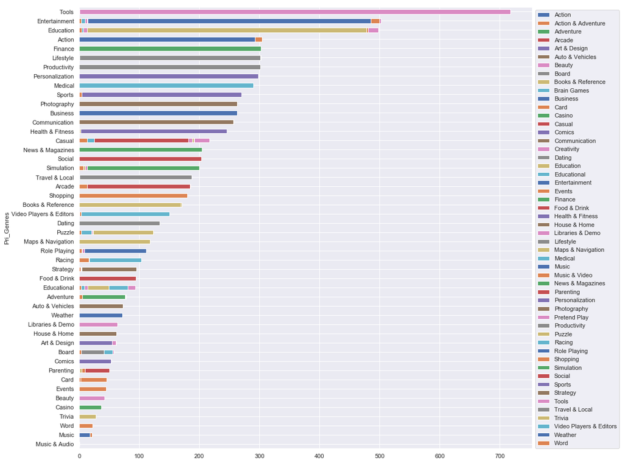

```python
# to visualize it (we ignore colunm 'Total' here)
table_cate.sort_values(by='Total', ascending=True).iloc[:,:-1].plot(kind="barh", figsize=(15,15),stacked=True);
plt.legend(bbox_to_anchor=(1.0,1.0))
```

There are too many information, let's only focus on **top 10** genres!

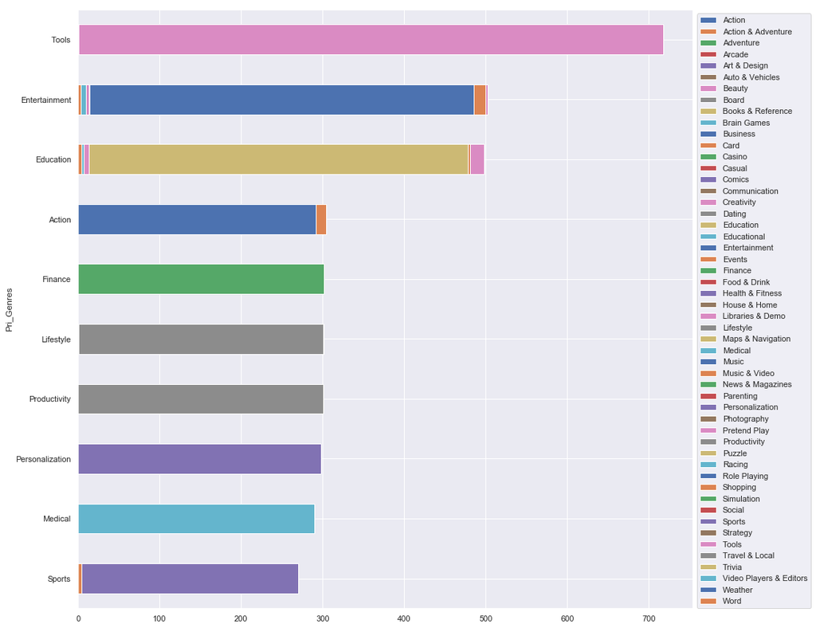

```python
# to see top 10 primary genres and the proportion of their secondary genres (we ignore colunm 'Total' here)
table_cate.sort_values(by='Total', ascending=True).iloc[:,:-1].tail(10).plot(kind="barh", figsize=(15,15),stacked=True);
plt.legend(bbox_to_anchor=(1.0,1.0))
```

Summary for Genres: Tools is the biggest primary genres, in which almost the secondary genres is almost Tools only. Entertainment and Education are also big genres. And we also found that for these top primary genres, their biggest secondary genres name are same as the primary's (i.e.: Entertainment's biggest secondary genres is Entertainment)

#### 4.1.10 Last Updated

- Convert the data to datetime format
- Taking a difference between last updated date and today to simplify
- Create a new column called 'Last_Updated_Days': integer indicating how many days passed since last update

```python
from datetime import datetime,date
temp=pd.to_datetime(app['Last Updated'])
temp.to_frame().head()
```

|  | Last Updated |
| --- | --- |
| 0 | 2018-01-07 |
| 1 | 2018-01-15 |
| 2 | 2018-08-01 |
| 3 | 2018-06-08 |
| 4 | 2018-06-20 |

```python
app['Last_Updated_Days'] = temp.apply(lambda x:date.today()-datetime.date(x))
app['Last_Updated_Days'] = app.Last_Updated_Days.apply(lambda x: str(x).split(' ')[0])
app['Last_Updated_Days'] = pd.to_numeric(app.Last_Updated_Days)
```

```python
# The top 10 app that hasn't been updated for the longest time
app[['App','Last_Updated_Days']].sort_values(by='Last_Updated_Days',ascending=False).head()
```

|  | App | Last_Updated_Days |
| --- | --- | --- |
| 7479 | FML F*ck my life + widget | 3279 |
| 7430 | CJ Poker Odds Calculator | 3025 |
| 10282 | FD Shift Calendar Widget | 2980 |
| 8418 | DEER HUNTER CHALLENGE | 2954 |
| 8084 | Freecell CY | 2949 |

Summary: It seems like there are many 'abandoned' apps that have not been updated for more than 5 years... This created column might be very useful to predict a successful app since the more popular the app, the more frequently it will be updated.

### 4.2 Data Cleaning for Review (googleplaystore_user_reviews.csv)

```python
reviews = pd.read_csv('googleplaystore_user_reviews.csv', header=0)
reviews.head()
```

|  | App | Translated_Review | Sentiment | Sentiment_Polarity | Sentiment_Subjectivity |
| --- | --- | --- | --- | --- | --- |
| 0 | 10 Best Foods for You | I like eat delicious food. That's I'm cooking ... | Positive | 1.00 | 0.533333 |
| 1 | 10 Best Foods for You | This help eating healthy exercise regular basis | Positive | 0.25 | 0.288462 |
| 2 | 10 Best Foods for You | NaN | NaN | NaN | NaN |
| 3 | 10 Best Foods for You | Works great especially going grocery store | Positive | 0.40 | 0.875000 |
| 4 | 10 Best Foods for You | Best idea us | Positive | 1.00 | 0.300000 |

#### 4.2.1 Overall Dataset

- Drop null values
- Check data types

```python
#Size of data frame
print('There are {} rows Before data cleaning.'.format(reviews.shape[0]))
# drop the rows that contain missing value
reviews = reviews.dropna()
print('There are {} rows After data cleaning.'.format(reviews.shape[0]))
```

```
There are 64295 rows Before data cleaning.
There are 37427 rows After data cleaning.
```

```python
# Check data type (no need to convert)
reviews.dtypes
```

```
App                        object
Translated_Review          object
Sentiment                  object
Sentiment_Polarity        float64
Sentiment_Subjectivity    float64
dtype: object
```

#### 4.2.2 Translated_Review (Text Process)

- Lower case
- Removal of Punctuation
- Removal of Stop Words
- Lemmatizataion

```python
# show all sentence
pd.set_option('display.max_colwidth', -1)
reviews['Translated_Review'].to_frame().head()
```

|  | Translated_Review |
| --- | --- |
| 0 | I like eat delicious food. That's I'm cooking food myself, case "10 Best Foods" helps lot, also "Best Before (Shelf Life)" |
| 1 | This help eating healthy exercise regular basis |
| 3 | Works great especially going grocery store |
| 4 | Best idea us |
| 5 | Best way |

```python
# Lower case
reviews['Translated_Review'] = reviews['Translated_Review'].apply(lambda x: " ".join(x.lower() for x in x.split()))
reviews['Translated_Review'].to_frame().head(3)
```

|  | Translated_Review |
| --- | --- |
| 0 | i like eat delicious food. that's i'm cooking food myself, case "10 best foods" helps lot, also "best before (shelf life)" |
| 1 | this help eating healthy exercise regular basis |
| 3 | works great especially going grocery store |

```python
# Removing Punctuation (remove all Punctuation except words and space)
reviews['Translated_Review'] = reviews['Translated_Review'].str.replace('[^\w\s]','')
reviews['Translated_Review'].to_frame().head(3)
```

|  | Translated_Review |
| --- | --- |
| 0 | i like eat delicious food thats im cooking food myself case 10 best foods helps lot also best before shelf life |
| 1 | this help eating healthy exercise regular basis |
| 3 | works great especially going grocery store |

```python
# Removal of Stop Words and also some other words
from nltk.corpus import stopwords
stop = stopwords.words('english')
added = ['ive','im','us','star','would','go','even','5','live','give','get']
reviews['Translated_Review'] = reviews['Translated_Review'].apply(lambda x: " ".join(x for x in x.split()
                                                                            if x not in stop and x not in added))
reviews['Translated_Review'].to_frame().head(5)
```

|  | Translated_Review |
| --- | --- |
| 0 | like eat delicious food thats cooking food case 10 best foods helps lot also best shelf life |
| 1 | help eating healthy exercise regular basis |
| 3 | works great especially going grocery store |
| 4 | best idea |
| 5 | best way |

```python
# Lemmatizataion (convert helps to help)
lmtzr = WordNetLemmatizer()
reviews['Translated_Review'] = reviews['Translated_Review'].apply(lambda x: " ".join(lmtzr.lemmatize(x,pos='v') for x in x.split()))
reviews['Translated_Review'].to_frame().head(5)
```

|  | Translated_Review |
| --- | --- |
| 0 | like eat delicious food thats cook food case 10 best foods help lot also best shelf life |
| 1 | help eat healthy exercise regular basis |
| 3 | work great especially go grocery store |
| 4 | best idea |
| 5 | best way |

### 4.3 Feature Engineering

In this section, we will further learn about all of our columns, and carry out more in-depth data processing on them to select suitable variables for **4.4 Modeling**. And, more importantly, we can answer part of objective questions at this point:

- 4.3.1 Rating:
  1. Rating distribution in different categories: Whether ratings show difference in different categories?
  2. Is that difference is statistically significant, or not?
  3. Relationship between other variable and rating: How other app features impact on rating?
  4. What is the most influencial feature?
- 4.3.2 Pricing:
  1. Free VS Paid: What is the proportion of free app?
  2. For paid apps, what is the pricing distribution for them?
  3. Price distribution in different categories
  4. Relationship between other variables and price
- 4.3.3 Reviews:
  1. What is the number of comments most people have, long comments or short comments?
  2. High-frequency positive words for an app category: What customers appreciate most for apps ?
  3. High-frequency negative words for an app category: What customers complaint most for apps ?

We answer these questions by delivering infomative visualizations such as, using 'groupby' or 'pivot_table' methods, and creating correlation matrix with analysis. Then, ideally, these steps would help us on feature selection. We also learnt that modeling methods such as PCA and Random Forest will help us on chooseing features based on prediction, but we may cover these methods in the next stage.

#### 4.3.1 Rating

**1. Rating distribution in different categories: Whether ratings show difference in different categories?**

If we only look at the violinplot, the difference between apps of different categories in rating seems not so obvious. Basically, most of the rating of all categories are distributed **around the average (blue line)**. In order to see the distribution of different categories in rating more specifically, we use 'pivot_table' to summarize the categories with average rating exceeding average rating. After observing the rating of these categories, it seems that apps in different categories are all fairly good on rating. But is that really the case? This question leads to our next finding.

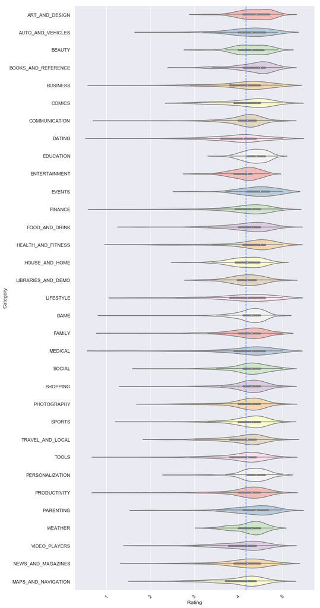

```python
fig, ax = plt.subplots(figsize=(10,25))
sns.violinplot(y="Category", x="Rating", data=app, palette="Pastel1",orient='h')
plt.xticks(rotation=45)
ax.axvline(4.17, ls='--')
```

```python
# Categories with average rating exceed average rating: 4.17.
rate_cate = app.pivot_table(index=['Category'],values=['Rating'],aggfunc='mean')
rate_cate[rate_cate['Rating']>np.mean(app['Rating'])].sort_values(by='Rating',ascending=False)
```

| Category | Rating |
| --- | --- |
| EVENTS | 4.435556 |
| EDUCATION | 4.364407 |
| ART_AND_DESIGN | 4.357377 |
| BOOKS_AND_REFERENCE | 4.344970 |
| PERSONALIZATION | 4.332215 |
| PARENTING | 4.300000 |
| BEAUTY | 4.278571 |
| GAME | 4.247368 |
| SOCIAL | 4.247291 |
| WEATHER | 4.243056 |
| HEALTH_AND_FITNESS | 4.243033 |
| SHOPPING | 4.230000 |
| SPORTS | 4.216154 |
| AUTO_AND_VEHICLES | 4.190411 |
| PRODUCTIVITY | 4.183389 |
| COMICS | 4.181481 |
| FAMILY | 4.179664 |
| LIBRARIES_AND_DEMO | 4.178125 |

**2. Is that difference statistically significant, or not?**

In order to verify whether all these different categories perform equally well in rating, we apply one-way analysis of variance（ANOVA) to calculate the p-value of these series. The one-way analysis of variance (ANOVA) is used to determine whether there are any statistically significant differences between the means of two or more groups. Results show that the average app ratings across categories is **significantly different**, and the p-value is very small, only 3.45e-30. In other words, app scores are higher in some categories and lower in others.

Next, we tried to find which category is always different from other categories on rating. Then we made a heatmap to **see p-values of one-way ANOVA analysis between each pairs of categories**. The darker the cell, the smaller the p-value for the pairs of categories on rating and the more the dark cells in a either row or column, the more different the category has different performance on rating from others. We find there are several categories that are significantly different from others, such as' EDUCATION, ' 'DATING,' and 'PERSONALIZATION.' In reality, for apps in the 'EDUCATION'category, users tend to have high income or high education, tend to give a relatively fair score when scoring, and even consciously do not give a low score. 'PERSONALIZATION' apps often provide users customized content and services, thus earning higher evaluation. However, in the category of 'DATING', users may give low scores irrationally for some personal reasons.

```python
def group(s=app['Category']):
    name_dict={}
    for name in s:
        name_dict[name] = app[app['Category'] == name]['Rating'].values
    return name_dict
cate_dict = group()
```

```python
ART_AND_DESIGN = cate_dict.get('ART_AND_DESIGN')
AUTO_AND_VEHICLES = cate_dict.get('AUTO_AND_VEHICLES')
BEAUTY = cate_dict.get('BEAUTY')
BOOKS_AND_REFERENCE = cate_dict.get('BOOKS_AND_REFERENCE')
BUSINESS = cate_dict.get('BUSINESS')
COMICS = cate_dict.get('COMICS')
COMMUNICATION = cate_dict.get('COMMUNICATION')
DATING = cate_dict.get('DATING')
EDUCATION = cate_dict.get('EDUCATION')
ENTERTAINMENT = cate_dict.get('ENTERTAINMENT')
EVENTS = cate_dict.get('EVENTS')
FINANCE = cate_dict.get('FINANCE')
FOOD_AND_DRINK = cate_dict.get('FOOD_AND_DRINK')
HEALTH_AND_FITNESS = cate_dict.get('HEALTH_AND_FITNESS')
HOUSE_AND_HOME = cate_dict.get('HOUSE_AND_HOME')
LIBRARIES_AND_DEMO = cate_dict.get('LIBRARIES_AND_DEMO')
LIFESTYLE = cate_dict.get('LIFESTYLE')
GAME = cate_dict.get('GAME')
FAMILY = cate_dict.get('FAMILY')
MEDICAL = cate_dict.get('MEDICAL')
SOCIAL = cate_dict.get('SOCIAL')
SHOPPING = cate_dict.get('SHOPPING')
PHOTOGRAPHY = cate_dict.get('PHOTOGRAPHY')
SPORTS = cate_dict.get('SPORTS')
TRAVEL_AND_LOCAL = cate_dict.get('TRAVEL_AND_LOCAL')
TOOLS = cate_dict.get('TOOLS')
PERSONALIZATION = cate_dict.get('PERSONALIZATION')
PRODUCTIVITY = cate_dict.get('PRODUCTIVITY')
PARENTING = cate_dict.get('PARENTING')
WEATHER = cate_dict.get('WEATHER')
VIDEO_PLAYERS = cate_dict.get('VIDEO_PLAYERS')
NEWS_AND_MAGAZINES = cate_dict.get('NEWS_AND_MAGAZINES')
MAPS_AND_NAVIGATION = cate_dict.get('MAPS_AND_NAVIGATION')
```

```python
# One-way ANOVA: for all 33 categories
stats.f_oneway(ART_AND_DESIGN, AUTO_AND_VEHICLES, BEAUTY, BOOKS_AND_REFERENCE, BUSINESS, COMICS, COMMUNICATION,
               DATING, EDUCATION, ENTERTAINMENT, EVENTS, FINANCE, FOOD_AND_DRINK, HEALTH_AND_FITNESS, HOUSE_AND_HOME,
               LIBRARIES_AND_DEMO, LIFESTYLE, GAME, FAMILY, MEDICAL, SOCIAL, SHOPPING, PHOTOGRAPHY, SPORTS,
               TRAVEL_AND_LOCAL, TOOLS, PERSONALIZATION, PRODUCTIVITY, PARENTING, WEATHER, VIDEO_PLAYERS,
               NEWS_AND_MAGAZINES, MAPS_AND_NAVIGATION)
```

```
F_onewayResult(statistic=6.9993549749623245, pvalue=3.4525319466034365e-30)
```

They are significantly different, we could know that the average ratings for different categories are different. Next, we tried to find **which category is always different** from other categories on rating. So we made a heatmap to see p-values of one-way ANOVA analysis between each pairs of categories.

```python
cate_list = [ART_AND_DESIGN, AUTO_AND_VEHICLES, BEAUTY, BOOKS_AND_REFERENCE, BUSINESS, COMICS, COMMUNICATION,
            DATING, EDUCATION, ENTERTAINMENT, EVENTS, FINANCE, FOOD_AND_DRINK, HEALTH_AND_FITNESS, HOUSE_AND_HOME,
            LIBRARIES_AND_DEMO, LIFESTYLE, GAME, FAMILY, MEDICAL, SOCIAL, SHOPPING, PHOTOGRAPHY, SPORTS,
            TRAVEL_AND_LOCAL, TOOLS, PERSONALIZATION, PRODUCTIVITY, PARENTING, WEATHER, VIDEO_PLAYERS,
            NEWS_AND_MAGAZINES, MAPS_AND_NAVIGATION]

ANOVA = pd.DataFrame(index=['ART_AND_DESIGN', 'AUTO_AND_VEHICLES', 'BEAUTY', 'BOOKS_AND_REFERENCE', 'BUSINESS',
                            'COMICS', 'COMMUNICATION', 'DATING', 'EDUCATION', 'ENTERTAINMENT', 'EVENTS',
                            'FINANCE', 'FOOD_AND_DRINK', 'HEALTH_AND_FITNESS', 'HOUSE_AND_HOME', 'LIBRARIES_AND_DEMO',
                            'LIFESTYLE', 'GAME', 'FAMILY', 'MEDICAL', 'SOCIAL','SHOPPING', 'PHOTOGRAPHY', 'SPORTS',
                            'TRAVEL_AND_LOCAL', 'TOOLS', 'PERSONALIZATION', 'PRODUCTIVITY', 'PARENTING', 'WEATHER',
                            'VIDEO_PLAYERS', 'NEWS_AND_MAGAZINES', 'MAPS_AND_NAVIGATION'],
                     columns=['ART_AND_DESIGN', 'AUTO_AND_VEHICLES', 'BEAUTY', 'BOOKS_AND_REFERENCE', 'BUSINESS',
                            'COMICS', 'COMMUNICATION', 'DATING', 'EDUCATION', 'ENTERTAINMENT', 'EVENTS',
                            'FINANCE', 'FOOD_AND_DRINK', 'HEALTH_AND_FITNESS', 'HOUSE_AND_HOME', 'LIBRARIES_AND_DEMO',
                            'LIFESTYLE', 'GAME', 'FAMILY', 'MEDICAL', 'SOCIAL','SHOPPING', 'PHOTOGRAPHY', 'SPORTS',
                            'TRAVEL_AND_LOCAL', 'TOOLS', 'PERSONALIZATION', 'PRODUCTIVITY', 'PARENTING', 'WEATHER',
                            'VIDEO_PLAYERS', 'NEWS_AND_MAGAZINES', 'MAPS_AND_NAVIGATION'])

for categories in cate_list:
    for i in range(len(cate_list)):
        for j in range(len(cate_list)):
            ANOVA.iloc[i,j] = stats.f_oneway(cate_list[i],cate_list[j])[1]

ANOVA.fillna(1,inplace=True)
```

We can find some categories with a large number of dark blocks in the heatmap, such as **EDUCATION, DATING and PERSONALIZATION**. These categories are obviously different from others on rating.

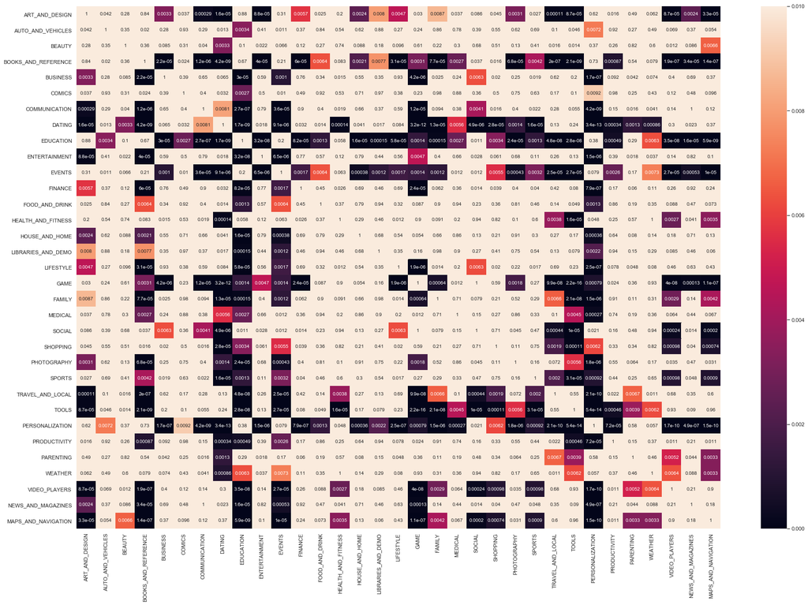

```python
f, ax = plt.subplots(figsize=(30, 20))
sns.heatmap(ANOVA, annot=True,vmax=0.01)
```

**3. Relationship between other variable and rating: How other app features impact on rating?**

We can only calculate the correlation rate for all numeric variables, so this correlation analysis is not particularly comprehensive. A more comprehensive analysis will be reflected in the modeling section later. As far as our visualized correlation rates are concerned, most of the correlations between numeric variables are **not very significant**.

In particular, the main variable we discussed, **Rating, is almost not correlated to any other single numeric variable,** but it might also suggest that rating is a variable reflected by multiple aspects of an app. In addition, it is worth to mention that the correlation between **Installs and Reviews reached 0.624**, indicating that these two variables showed **relatively strong positive correlation**. In the next stage Modeling, we will pay more attention to the interaction of these two variables.

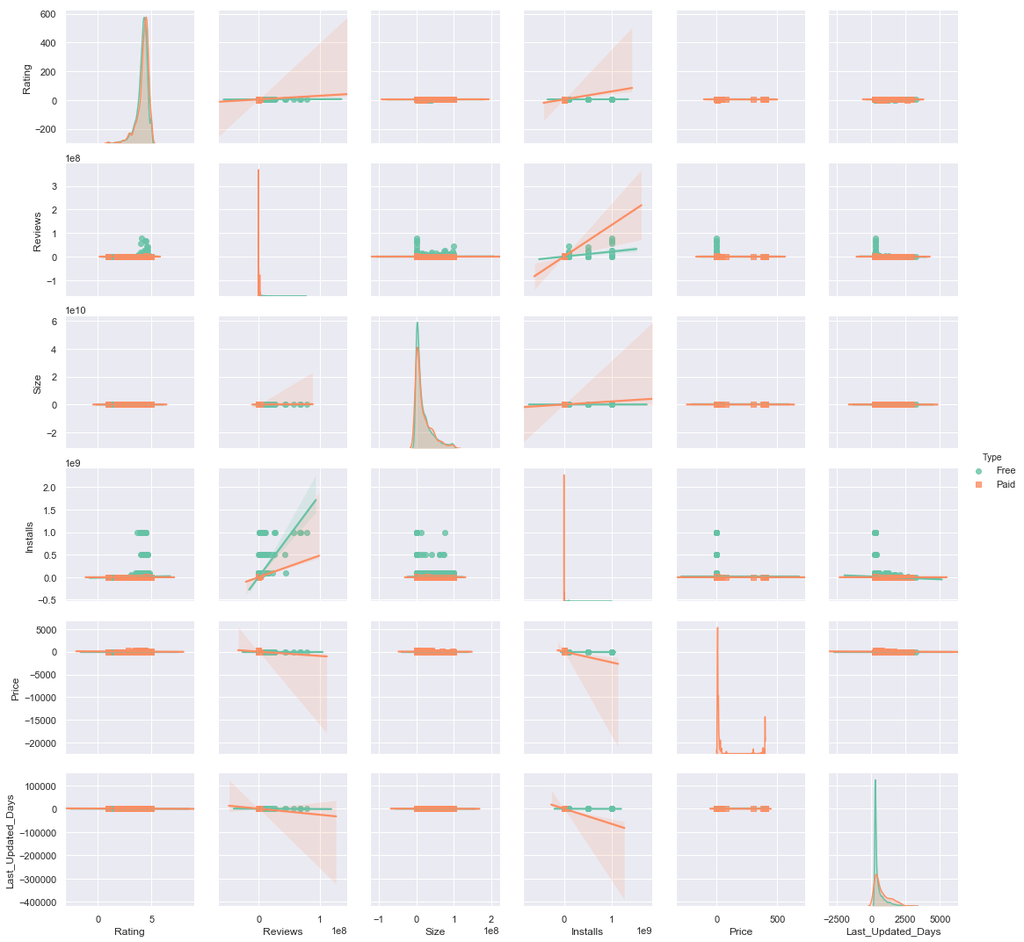

```python
sns.pairplot(app, kind="reg", hue="Type", markers=["o", "s"], palette="Set2")
```

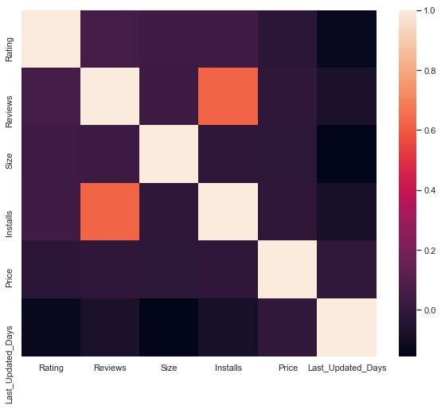

```python
f, ax = plt.subplots(figsize=(10, 8))
corr = app.iloc[:,[2,3,4,5,7,15]].corr()
sns.heatmap(corr, xticklabels=corr.columns.values, yticklabels=corr.columns.values)
```

```python
app['Installs'].corr(app.Reviews)
```

```
0.6240556233042991
```

#### 4.3.2 Pricing

**1. Free VS Paid: What is the proportion of free app?**

7592 out of 8196 apps are free, the proportion is 92.63%, which is very high. But are they really purely 'free' for users? The answer is probably NO.

Some free apps usually act as add-ons to an established product or service. The goal is not to make money directly from the app, but instead to drive people to other revenue streams. Those services ultimately make money for the company, even if the app itself has no price tag. Some free apps are platforms for ad revenue.

In addition, with the freemium pricing model, the app is free to download, but there are additional tiers, features or incentives within the app that users can choose to pay for. For example, KEEP, a very popular fitness app in China, is a free app to download but if you pay 19 RMB (2.79 USD) a month you could enjoy customized fitness schedule and more advanced classes. There are many other disguised charging strategies app developers usually use but all in all, in nowadays, Paid-for apps are indeed an unpopular option, and app developers should try to follow the trend.

Although there are not many paid apps, it is still worth studying the pricing trends and rules of these paid apps, which is what we will talk about in the next question.

```python
# column overview
app['Type'].value_counts()
```

```
Free    7592
Paid    604
Name: Type, dtype: int64
```

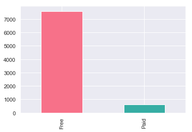

```python
app.Type.value_counts().plot(kind='bar', color=sns.color_palette("husl", 2))
```

**2. For paid apps, what is the pricing distribution for them?**

Among paid apps, the most apps are priced in the range of $2-3.

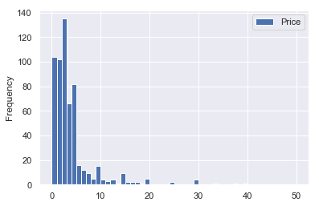

```python
Paid = app[app['Price']>0]
Paid.plot(y='Price', kind='hist', bins=50, range=(0,50))
```

**3. Price distribution in different categories**

We focus on the prices of four categories, **'FAMILY ', 'FINANCE', 'LIFESTYLE' and 'MEDICAL'**. 'FAMILY' has the most paid apps, while the latter three have the highest average app charges. We want to explore why these three categories of apps are particularly expensive. Through the price distribution, we find that the high prices of these three categories‘ apps are partly caused by very expensive apps.

By the price distribution, we find that the high price of these three categories is partly caused by several very expensive apps, as we also found in data cleaning. So, basically, if we don't take into account these extremely expensive apps, we can say that most of the paid apps are reasonably priced relatively.

```python
price_cate1 = app.pivot_table(index=['Category'],values=['Price'],aggfunc='mean')
df=pd.DataFrame(price_cate1)
df.sort_values(by=['Price'],ascending=False)
```

| Category | Price |
| --- | --- |
| FINANCE | 8.079040 |
| LIFESTYLE | 6.514551 |
| MEDICAL | 2.151276 |
| FAMILY | 1.406604 |
| PERSONALIZATION | 0.417047 |
| WEATHER | 0.408750 |
| SPORTS | 0.358500 |
| GAME | 0.304134 |
| TOOLS | 0.289554 |
| PHOTOGRAPHY | 0.274943 |
| BUSINESS | 0.244905 |
| PRODUCTIVITY | 0.235615 |
| MAPS_AND_NAVIGATION | 0.228390 |
| COMMUNICATION | 0.221445 |
| TRAVEL_AND_LOCAL | 0.200481 |
| PARENTING | 0.191600 |
| HEALTH_AND_FITNESS | 0.173730 |
| EDUCATION | 0.152203 |
| DATING | 0.141567 |
| BOOKS_AND_REFERENCE | 0.141302 |
| ART_AND_DESIGN | 0.097869 |
| FOOD_AND_DRINK | 0.090213 |
| ENTERTAINMENT | 0.078235 |
| VIDEO_PLAYERS | 0.070676 |
| SHOPPING | 0.030444 |
| AUTO_AND_VEHICLES | 0.027260 |
| NEWS_AND_MAGAZINES | 0.019510 |
| SOCIAL | 0.009754 |
| LIBRARIES_AND_DEMO | 0.000000 |
| EVENTS | 0.000000 |
| COMICS | 0.000000 |
| BEAUTY | 0.000000 |
| HOUSE_AND_HOME | 0.000000 |

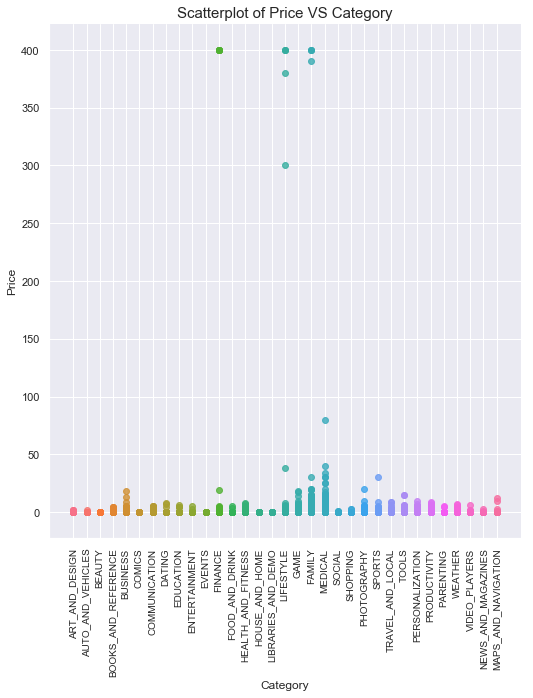

```python
sns.lmplot(x='Category', y='Price', data=app, fit_reg=False, legend=False,
           hue="Category",height=8)
plt.xticks(rotation=90,size=10)
plt.title('Scatterplot of Price VS Category',size = 15)
```

```python
#count the number of paid and free apps in each category
price_cate = app.pivot_table(index=['Category'],columns=['Type'],aggfunc='count')['App']
price_cate
```

| Type Category | Free | Paid |
| --- | --- | --- |
| ART_AND_DESIGN | 58.0 | 3.0 |
| AUTO_AND_VEHICLES | 72.0 | 1.0 |
| BEAUTY | 42.0 | NaN |
| BOOKS_AND_REFERENCE | 161.0 | 8.0 |
| BUSINESS | 254.0 | 9.0 |
| COMICS | 54.0 | NaN |
| COMMUNICATION | 234.0 | 22.0 |
| DATING | 131.0 | 3.0 |
| EDUCATION | 114.0 | 4.0 |
| ENTERTAINMENT | 100.0 | 2.0 |
| EVENTS | 45.0 | NaN |
| FAMILY | 1454.0 | 154.0 |
| FINANCE | 289.0 | 13.0 |
| FOOD_AND_DRINK | 92.0 | 2.0 |
| GAME | 836.0 | 76.0 |
| HEALTH_AND_FITNESS | 233.0 | 11.0 |
| HOUSE_AND_HOME | 62.0 | NaN |
| LIBRARIES_AND_DEMO | 64.0 | NaN |
| LIFESTYLE | 283.0 | 18.0 |
| MAPS_AND_NAVIGATION | 113.0 | 5.0 |
| MEDICAL | 227.0 | 63.0 |
| NEWS_AND_MAGAZINES | 202.0 | 2.0 |
| PARENTING | 48.0 | 2.0 |
| PERSONALIZATION | 233.0 | 65.0 |
| PHOTOGRAPHY | 248.0 | 15.0 |
| PRODUCTIVITY | 283.0 | 18.0 |
| SHOPPING | 178.0 | 2.0 |
| SOCIAL | 201.0 | 2.0 |
| SPORTS | 238.0 | 22.0 |
| TOOLS | 655.0 | 63.0 |
| TRAVEL_AND_LOCAL | 179.0 | 8.0 |
| VIDEO_PLAYERS | 144.0 | 4.0 |
| WEATHER | 65.0 | 7.0 |

```python
group = price_cate.loc[['FINANCE', 'LIFESTYLE', 'MEDICAL','FAMILY']]
group.index
```

```
Index(['FINANCE', 'LIFESTYLE', 'MEDICAL', 'FAMILY'], dtype='object', name='Category')
```

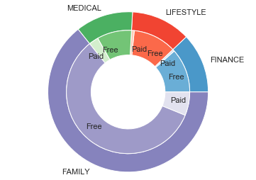

```python
a, b, c, d=[plt.cm.Blues, plt.cm.Reds, plt.cm.Greens, plt.cm.Purples]
fig, ax = plt.subplots()
ax.axis('equal')
mypie, _ = ax.pie(group.sum(axis=1), radius=1.3, labels=group.index, colors=[a(0.6), b(0.6), c(0.6), d(0.6)] )
plt.setp( mypie, width=0.3, edgecolor='white')
mypie2, _ = ax.pie(group.values.flatten().tolist(), labels=['Free','Paid']*4, radius=1.3-0.3, labeldistance=0.7, colors=[a(0.5), a(0.2), b(0.5), b(0.2), c(0.5), c(0.2),d(0.5),d(0.2)])
plt.setp( mypie2, width=0.4, edgecolor='white')
plt.margins(0,0)
plt.show()
```

**4. Relationship between other variables and price**

According to the first graph below, Paid apps have higher average rating than free apps but **WHY**? And from the second scatter plot, we can see that super expensive apps have lower rating. Maybe this is because that higher-priced apps may make customer disappointed, if they are not good enough. So the higher average rating of paid apps is defintely not caused by those extremely expensive apps, may be those low-charge apps are the biggest reason.

In order to provide evidence to our guess, we then divide the price range to four groups, Free (0), Cheap (1-10), Medium (10-50) and Expensive (>50), to see the rating of each group so that we could eliminate noise caused by too many Free apps and several super expensive apps. What we found is **Cheap apps achieved highest score (avg=4.27), Medium price apps (avg=4.22) perform slightly better on rating than Free apps (avg=4.16), and Expensive apps (avg=3.91) have very bad user feedback.** So we can conclude that the reason why paid apps have higher average rating than free apps is because the group with price ranging from 0 to 10 have higher average rating.

To be more specific, we can infer that many cheap paid apps (price < $10) are very well-designed and generate very nice user experience with additional premium functions and outstanding solutions that make customers are willing to pay even though they have many other free options.

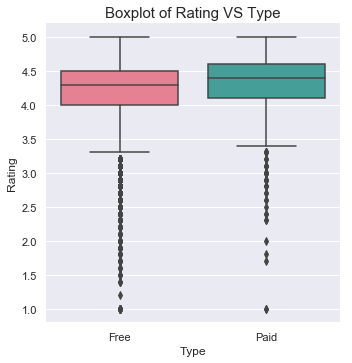

```python
g = sns.catplot(x="Type",y="Rating",data=app, kind="box", height = 5,palette = "husl")
g.despine(left=True)
g.set( xticks=range(0,2))
g = g.set_ylabels("Rating")
plt.title('Boxplot of Rating VS Type',size = 15)
```

This boxplot showed that paid apps have higher rating than free apps. But through the scatterplot, we find that price and rating are negatively correlated. What contributed to this contradiction?

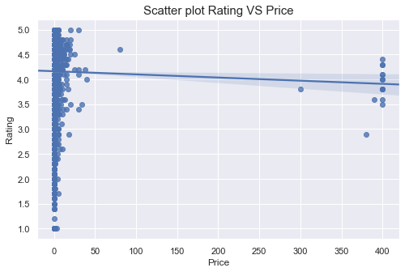

```python
plt.figure(figsize = (8,5))
sns.regplot(x="Price", y="Rating", color = 'b',data=app[app['Reviews']<1000000]);
plt.title('Scatter plot Rating VS Price',size = 15)
```

```python
price_rate = app[['Price','Rating']]
```

```python
price_rate.loc[ price_rate['Price'] == 0, 'PriceBand'] = 'Free'
price_rate.loc[(price_rate['Price'] > 0) & (price_rate['Price'] <= 10), 'PriceBand'] = 'Cheap'
price_rate.loc[(price_rate['Price'] > 10) & (price_rate['Price'] <= 50), 'PriceBand'] = 'Medium'
price_rate.loc[(price_rate['Price'] > 50), 'PriceBand']  = 'Expensive'
```

```python
price_rate[['PriceBand', 'Rating']].groupby(['PriceBand'], as_index=False).mean()
```

|  | PriceBand | Rating |
| --- | --- | --- |
| 0 | Cheap | 4.272628 |
| 1 | Expensive | 3.912500 |
| 2 | Free | 4.166372 |
| 3 | Medium | 4.220000 |

This plot explained the contradiction between boxplot and scatter plot we made above. The higher average price of paid apps is contributed by apps in the "Cheap" category. In other words, the high rating of cheap apps compensated the low rating of expensive apps, making the whole paid app group has a higher rating compared to the free apps.

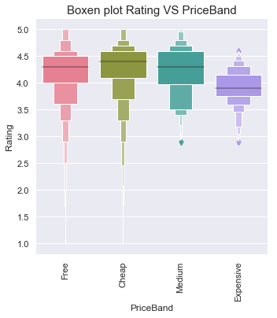

```python
g = sns.catplot(x="PriceBand",y="Rating",data=price_rate, kind="boxen", height = 5 ,palette = "husl")
g.despine(left=True)
g.set_xticklabels(rotation=90)
g = g.set_ylabels("Rating")
plt.title('Boxen plot Rating VS PriceBand',size = 15)
```

#### 4.3.3 Review

**1. What is the number of comments most people have, long comments or short comments?**

```python
# how many words in Positive reviews
Ptext_word_counts = reviews[reviews['Sentiment']=='Positive'].Translated_Review.apply(lambda x:
                                                                                      len(str(x).split(" ")))
# how many words in Negative reviews
Ntext_word_counts = reviews[reviews['Sentiment']=='Negative'].Translated_Review.apply(lambda x:
                                                                                      len(str(x).split(" ")))
print('There are {} Positive reviews and {} Negative reviews.'.format(Ptext_word_counts.count(),
                                                                     Ntext_word_counts.count()))
```

```
There are 23998 Positive reviews and 8271 Negative reviews.
```

```python
# Most common number of words in Positive reviews (Top 5)
Ptext_word_counts.value_counts(sort=True)[:5]
```

```
1    2129
2    1423
3    1230
4    1048
5    1000
Name: Translated_Review, dtype: int64
```

```python
# Most common number of words in Negative reviews (Top 5)
Ntext_word_counts.value_counts(sort=True)[:5]
```

```
11    312
12    310
9     310
8     297
3     297
Name: Translated_Review, dtype: int64
```

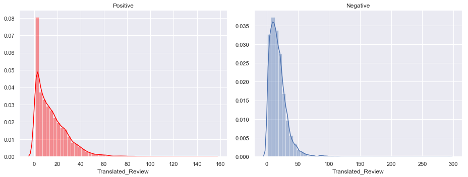

```python
# The distribution of the number of words in positive and negative comments
f, axes = plt.subplots(1, 2, figsize=(13, 5))
sns.distplot(Ptext_word_counts , color="red",ax=axes[0],label='Positive').set_title('Positive')
sns.distplot(Ntext_word_counts , color="b").set_title('Negative')
plt.tight_layout()
```

Comments are great feedback for application developers. Positive feedback encourages developers, and negative feedback also helps developers improve the quality of apps. We counted the number of words of each positive comment, and calculated the frequency too see how the extent to which people are willing to share their opinions about the apps.

Unfortunately, most people don't bother to take the time to give specific comments. No matter positive or negative comments, most users tend to make short comments. The longest comment had 300 words， which is negative. Most people's comments are less than 50 words and people who gave only one word of comment were the most. People are more reluctant to spend time on positive comments. Our analysis on reviews has been limited due to the above reasons.

Obviously, developers or the Google App Store didn't do a good job on effectively encouraging users to leave comments. To some extent, this suggests that they are underestimating the importance of comments or that increasing the number of comments is a costly task. However, developers need to take comments seriously as an important channel for gaining user experience. If there are some keywords or phrases available for users to choose when commenting (without direct input from users), it is likely to get more information. And it is also convenient for developers to review and analyze comments. The keywords can be "improve efficiency", "easy to use" or "I will recommend it to my friends", which can save users time and help developers understand more user experience as well.

**2. High-frequency positive adjective words: What customers appreciate most for apps ?**

```python
Positive_words = reviews[reviews['Sentiment']=='Positive'].Translated_Review
# Counter from Collections Module
P_words = " ".join(Positive_words).split()
Counter(P_words).most_common(10)
```

```
[('game', 5618),
 ('good', 4826),
 ('love', 4723),
 ('great', 4530),
 ('like', 4080),
 ('app', 3574),
 ('time', 3512),
 ('use', 3072),
 ('work', 3048),
 ('make', 2722)]
```

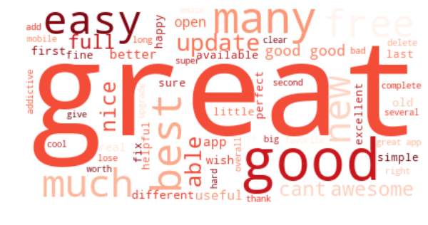

```python
# select and combine all comments from Positive review
Positive_text = " ".join(review for review in reviews[reviews['Sentiment']=='Positive'].Translated_Review)
P_tokens = nltk.word_tokenize(Positive_text)
P_tags = nltk.pos_tag(P_tokens)
Positive_adj = [word for word, pos in P_tags if (pos == 'JJ' or pos == 'JJR' or pos == 'JJS')]
# JJ adjective ‘big’ # JJR adjective, comparative ‘bigger’ # JJS adjective, superlative ‘biggest’

# Create and generate a word cloud image
plt.figure(figsize=(10,10))
wordcloud = WordCloud(max_font_size=1000, max_words=60,
                      background_color='white',colormap="Reds").generate(" ".join(Positive_adj))
# Display the generated image:
plt.imshow(wordcloud, interpolation='bilinear')
plt.axis("off")
plt.show()
```

```python
Text(P_words).collocations(20)
```

```
full review; please fix; highly recommend; easy use; many ads; user
friendly; every time; latest update; great app; love app; love game;
keep track; work fine; much better; wish could; free version; five
star; really like; work well; spend money
```

```python
#bigrams
bigrams = nltk.collocations.BigramAssocMeasures()
bigramFinder_P = nltk.collocations.BigramCollocationFinder.from_words(P_words,window_size=2)
bigram_freq = bigramFinder_P.ngram_fd.items()
bigramFreqTable = pd.DataFrame(list(bigram_freq), columns=['bigram','freq']).sort_values(by='freq', ascending=False)
bigramFreqTable.head(10)
```

|  | bigram | freq |
| --- | --- | --- |
| 963 | (love, game) | 532 |
| 410 | (love, app) | 451 |
| 48 | (great, app) | 445 |
| 465 | (easy, use) | 420 |
| 1638 | (please, fix) | 395 |
| 985 | (great, game) | 365 |
| 170 | (full, review) | 359 |
| 1016 | (many, ads) | 334 |
| 1236 | (every, time) | 323 |
| 996 | (good, game) | 316 |

```python
#trigrams
trigrams = nltk.collocations.TrigramAssocMeasures()
trigramFinder_P = nltk.collocations.TrigramCollocationFinder.from_words(P_words,window_size=3)
trigram_freq = trigramFinder_P.ngram_fd.items()
trigramFreqTable = pd.DataFrame(list(trigram_freq), columns=['trigram','freq']).sort_values(by='freq', ascending=False)
```

```python
trigramFreqTable.head(10)
```

|  | trigram | freq |
| --- | --- | --- |
| 408 | (keep, good, work) | 88 |
| 1098 | (way, many, ads) | 74 |
| 25154 | (best, game, ever) | 73 |
| 6599 | (love, love, love) | 73 |
| 25155 | (game, ever, play) | 60 |
| 1073 | (game, love, game) | 54 |
| 18749 | (love, game, much) | 42 |
| 2829 | (really, like, app) | 40 |
| 3753 | (every, time, try) | 37 |
| 34816 | (great, time, killer) | 37 |

When a user downloads an app, the first thing they see is ratings and reviews. Comprehensive reviews can help new users choose apps efficiently and also help developers improve the app. Reviews are a direct reflection of the app quality and user experiences.

Among all the positive comments of apps, we can find that popular apps share some common features through the analysis of word frequency. Aside from complimentary words like great, good, the keywords in the word cloud have **free**, **clear**, **helpful**, **available**, and the key phrases has **user friendly**, **free version**, **work well**, **latest update** and more. From these words, we can conclude users care about whether apps are useful, whether app updates regularly and whether they are easy to use when judging an app. Developers who always keep those in mind when developing new apps are more likely to succeed.

Besides, the word frequency of **"game"** is very high, which may be because compared with other types of apps, users are more inclined to review game apps, which should be noticed by developers. Negative words like **"way, many, ads"** with high frequency also appear in positive comments, this reminds developers that they may need to adjust the play frequency and length of the ads.

**3. High-frequency negative adjective words: What customers complaint most for the apps ?**

```python
Negative_words = reviews[reviews['Sentiment']=='Negative'].Translated_Review
# Counter from Collections Module
N_words = " ".join(Negative_words).split()
Counter(N_words).most_common(10)
```

```
[('game', 4537),
 ('time', 1786),
 ('play', 1501),
 ('like', 1324),
 ('cant', 1085),
 ('make', 1069),
 ('update', 1041),
 ('work', 1009),
 ('app', 908),
 ('ads', 877)]
```

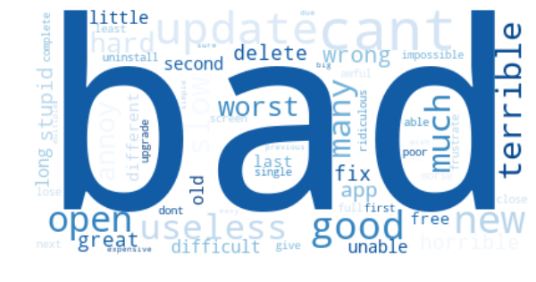

```python
# select and combine all comments from Negative review
Negative_text = " ".join(review for review in reviews[reviews['Sentiment']=='Negative'].Translated_Review)

# select all Negative adjective words
N_tokens = nltk.word_tokenize(Negative_text)
N_tags = nltk.pos_tag(N_tokens)
Negative_adj = [word for word, pos in N_tags if (pos == 'JJ' or pos == 'JJR' or pos == 'JJS')]
# JJ adjective ‘big’ # JJR adjective, comparative ‘bigger’ # JJS adjective, superlative ‘biggest’

# Create and generate a word cloud image
plt.figure(figsize=(10,10))
wordcloud = WordCloud(max_font_size=1000, max_words=60,
                      background_color='white',colormap="Blues").generate(" ".join(Negative_adj))
# Display the generated image:
plt.imshow(wordcloud, interpolation='bilinear')
plt.axis("off")
plt.show()
```

```python
Text(N_words).collocations(20)
```

```
please fix; waste time; every time; love game; play game; angry bird;
gift card; every single; spend money; candy crush; long time; take
forever; last update; many ads; credit card; dont waste; worst ever;
full review; take long; new update
```

```python
#bigrams
bigramFinder_N = nltk.collocations.BigramCollocationFinder.from_words(N_words,window_size=2)
bigram_freq = bigramFinder_N.ngram_fd.items()
bigramFreqTable = pd.DataFrame(list(bigram_freq), columns=['bigram','freq']).sort_values(by='freq', ascending=False)
bigramFreqTable.head(10)
```

|  | bigram | freq |
| --- | --- | --- |
| 141 | (play, game) | 355 |
| 903 | (love, game) | 239 |
| 4 | (waste, time) | 226 |
| 2034 | (please, fix) | 226 |
| 51 | (every, time) | 210 |
| 139 | (like, game) | 157 |
| 140 | (game, play) | 155 |
| 1046 | (game, like) | 103 |
| 1408 | (fun, game) | 100 |
| 8012 | (long, time) | 98 |

```python
# trigrams
trigramFinder_N = nltk.collocations.TrigramCollocationFinder.from_words(N_words,window_size=3)
trigram_freq = trigramFinder_N.ngram_fd.items()
trigramFreqTable = pd.DataFrame(list(trigram_freq), columns=['trigram','freq']).sort_values(by='freq', ascending=False)
```

```python
trigramFreqTable.head(10)
```

|  | trigram | freq |
| --- | --- | --- |
| 504 | (dont, waste, time) | 53 |
| 1029 | (take, forever, load) | 30 |
| 1991 | (every, single, time) | 29 |
| 854 | (really, like, game) | 29 |
| 6595 | (game, ever, play) | 26 |
| 1327 | (game, like, game) | 23 |
| 10307 | (take, long, time) | 23 |
| 2647 | (every, time, try) | 22 |
| 6110 | (way, many, ads) | 20 |
| 24736 | (cant, play, game) | 20 |

Compared with positive comments, negative comments also have **way, many, ads** in high-frequency words, which suggest the arrangement of ads are the problem for both good apps and bad apps. More noteworthy is the most complaining comments in negative comments are about time, **slow**, **take, forever, load** , **long, time**, which reflects the need to improve the loading time of the app which receives negative comments; **waste, time** suggest the need to improve the quality and content of bad apps. In negative reviews, the features of apps that users pay attention to are basically the same as those of positive reviews. They all have keywords about cost, usefulness, and update.

Users are seeking for apps that can genuinely help them, easy to learn and use, update and fix problems regularly.Developers should pay attention to these aspects to improve the user experience when creating new apps.

### 4.4 Modeling & Findings

In this section, we describe the work in the next phase of the report, the specific tasks are as follows:

- 4.4.1 Modeling for Rating
- 4.4.2 Findings from Rating
- 4.4.3 Logistic Regression Model for Pricing
- 4.4.4 Tree for Pricing (Free VS Paid)
- 4.4.5 Random Forest for Pricing(Free VS Paid)
- 4.4.6 Linear Regression for Pricing
- 4.4.7 Findings from Pricing

#### 4.4.1 Modeling for Rating

- Simple Multilinear Regression
- PCA
- Random Forest

In the following sections, we will focus on modeling analysis and prediction of rating. Our analysis starts with a simple linear regression, with the relevant findings and considerations in the feature engineering section mentioned above. We soon found that the **RMSE for baseline (average score) was very low at 0.36**, which meant that our modeling process would be difficult to be of practical value. **Linear's prediction results can only reach RMSE of 2.2**.

We know that the modeling value of the dataset variables may not be very nice, so we hope to use PCA to reduce the dimensions of our data. But the effect of PCA is not very good, the **PC1 has only 32.89% explained variance ratio.**

**Random forest** was the last model we tried. Compared with linear, **RMSE decreased significantly, only 0.49**, but it still could not be lower than RMSE of baseline. However, we also obtained some variable importance information, such as Reviews and Last_Updated_Days, which are of great importance for the prediction rating. Last_Updated_Days, as a variable created by ourselves, shows its value in this step.

```python
from sklearn.model_selection import train_test_split, KFold, GridSearchCV
from sklearn.preprocessing import StandardScaler
from sklearn.linear_model import LinearRegression, LogisticRegression
from sklearn.metrics import mean_squared_error,confusion_matrix,accuracy_score
from sklearn.ensemble import RandomForestRegressor,RandomForestClassifier
from sklearn.decomposition import PCA
from sklearn.tree import DecisionTreeRegressor,export_graphviz
```

```python
X = app[['Reviews', 'Size','Installs','Price','Last_Updated_Days']]
y = app['Rating']
# Create train/test split
X_train, X_test, y_train, y_test = train_test_split(X, y, test_size=0.2, random_state=1234)
```

**Baseline**

```python
baseline_preds = np.mean(y_test)
baseline_RMSE = np.mean(y_test.apply(lambda x: abs(baseline_preds-x)))
print('Average baseline error: ', round(baseline_RMSE, 2))
```

```
Average baseline error:  0.36
```

**Multilinear Regression**

```python
linear = sm.OLS(y_train, X_train).fit()
predictions = linear.predict(X_train)
linear.summary()
```

OLS Regression Results

| Dep. Variable: | Rating | R-squared: | 0.729 |
| --- | --- | --- | --- |
| Model: | OLS | Adj. R-squared: | 0.729 |
| Method: | Least Squares | F-statistic: | 3532. |
| Date: | Mon, 13 May 2019 | Prob (F-statistic): | 0.00 |
| Time: | 18:52:56 | Log-Likelihood: | -14435. |
| No. Observations: | 6556 | AIC: | 2.888e+04 |
| Df Residuals: | 6551 | BIC: | 2.891e+04 |
| Df Model: | 5 |  |  |
| Covariance Type: | nonrobust |  |  |

|  | coef | std err | t | P>\|t\| | [0.025 | 0.975] |
| --- | --- | --- | --- | --- | --- | --- |
| Reviews | 2.229e-08 | 1.64e-08 | 1.358 | 0.175 | -9.89e-09 | 5.45e-08 |
| Size | 5.197e-08 | 1.05e-09 | 49.599 | 0.000 | 4.99e-08 | 5.4e-08 |
| Installs | 5.064e-09 | 5.57e-10 | 9.090 | 0.000 | 3.97e-09 | 6.16e-09 |
| Price | 0.0048 | 0.002 | 2.698 | 0.007 | 0.001 | 0.008 |
| Last_Updated_Days | 0.0038 | 4.36e-05 | 86.688 | 0.000 | 0.004 | 0.004 |

| Omnibus: | 1018.487 | Durbin-Watson: | 1.516 |
| --- | --- | --- | --- |
| Prob(Omnibus): | 0.000 | Jarque-Bera (JB): | 1587.807 |
| Skew: | -1.093 | Prob(JB): | 0.00 |
| Kurtosis: | 4.016 | Cond. No. | 4.00e+06 |

Warnings:  
[1] Standard Errors assume that the covariance matrix of the errors is correctly specified.  
[2] The condition number is large, 4e+06. This might indicate that there are  
strong multicollinearity or other numerical problems.

```python
# Predict interest rate for test set, compare to actual interest rates
y_pred = linear.predict(X_test)
RMSE_lr = np.sqrt(mean_squared_error(y_test,y_pred))

print('RMSE of Multilinear Regression for Rating: ', round(RMSE_lr,2))
```

```
RMSE of Multilinear Regression for Rating:  2.19
```

**PCA**

```python
x = app.loc[:,['Reviews', 'Size','Installs','Price','Last_Updated_Days']].values
x = StandardScaler().fit_transform(x)
pca = PCA(n_components=2)
principalComponents = pca.fit_transform(x)
principalDf = pd.DataFrame(data = principalComponents
             , columns = ['principal component 1', 'principal component 2'])
pca.explained_variance_ratio_
```

```
array([0.3289219 , 0.22813322])
```

**Random Forest using 200 trees**

```python
X = pd.get_dummies(app[['Category','Reviews','Size','Installs','Price','Last_Updated_Days']],
                            columns=['Category'])
y_train = np.asarray(app['Rating'])
X_train, X_test, y_train, y_test = train_test_split(X, y, test_size=0.2, random_state=1234)
```

```python
regr=RandomForestRegressor(n_estimators=200,random_state=1234)
regr.fit(X_train,y_train)
y_pred=regr.predict(X_test)
RMSE_regr = np.sqrt(mean_squared_error(y_test,y_pred))
print('RMSE of Random Forest Regression for Rating: ',round(RMSE_regr,2))
```

```
RMSE of Random Forest Regression for Rating:  0.49
```

**Importance Features**

```python
feature_imp = pd.Series(regr.feature_importances_,index=X.columns).sort_values(ascending=False)
feature_imp
```

```
Reviews                         0.260255
Last_Updated_Days               0.217704
Size                            0.177748
Installs                        0.098439
Price                           0.024680
Category_FAMILY                 0.017808
Category_TOOLS                  0.016644
Category_LIFESTYLE              0.013699
Category_HEALTH_AND_FITNESS     0.012797
Category_FINANCE                0.012530
Category_DATING                 0.012390
Category_BUSINESS               0.011009
Category_MEDICAL                0.010112
Category_PRODUCTIVITY           0.009935
Category_GAME                   0.008729
Category_VIDEO_PLAYERS          0.008284
Category_COMMUNICATION          0.007992
Category_SPORTS                 0.007803
Category_NEWS_AND_MAGAZINES     0.007752
Category_PHOTOGRAPHY            0.007500
Category_TRAVEL_AND_LOCAL       0.006192
Category_SHOPPING               0.005468
Category_PERSONALIZATION        0.005280
Category_BOOKS_AND_REFERENCE    0.004846
Category_MAPS_AND_NAVIGATION    0.004810
Category_FOOD_AND_DRINK         0.004247
Category_AUTO_AND_VEHICLES      0.004246
Category_SOCIAL                 0.003768
Category_COMICS                 0.003754
Category_ENTERTAINMENT          0.002617
Category_PARENTING              0.002179
Category_LIBRARIES_AND_DEMO     0.001650
Category_BEAUTY                 0.001337
Category_HOUSE_AND_HOME         0.001271
Category_EVENTS                 0.001239
Category_EDUCATION              0.001182
Category_ART_AND_DESIGN         0.001120
Category_WEATHER                0.000986
dtype: float64
```

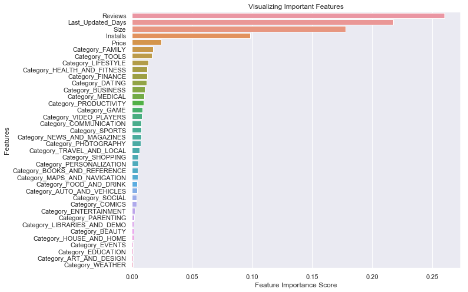

```python
f, ax = plt.subplots(figsize=(10, 8))
sns.barplot(x=feature_imp, y=feature_imp.index)
# Add labels to your graph
plt.xlabel('Feature Importance Score')
plt.ylabel('Features')
plt.title("Visualizing Important Features")
plt.show();
```

```python
app.Size.describe()
```

```
count    8.196000e+03
mean     1.865158e+07
std      2.237626e+07
min      0.000000e+00
25%      2.800000e+06
50%      9.400000e+06
75%      2.700000e+07
max      1.000000e+08
Name: Size, dtype: float64
```

#### 4.4.2 Findings from Rating

We found some interesting facts through modeling analysis. The RMSE of baseline is very low, which is hard to beat. However, at the same time, such a low RMSE is very interesting, which means that using the average score to predict the rating of an app is very accurate. It also reflects that many app users now tend to give a score of 4, which is neither high nor low. In real life when we're grading, 4 could actually be 4.5, 4 or 3.5. It seems like the 5-point scoring system cannot accurately reflect a user's evaluation of an app. This reminds me that IMDb is a 10-scale rating system, which enables people to easily distinguish between good movie(7-8), excellent movie(8-9) and classic movies(9-10). In addition to creating some difficulties for our prediction, the 5-point system might not good for app evaluation and this might be a good idea for Google App Store to consider using other scale, such 7 or 10.

Unfortunately, our current models cannot help us effectively predict the rating of an app. Probably, this variable is not very suitable to be regarded as a target variable in this dataset. However, we can still provide some useful information for app developers.

1. Under the existing scoring system (5-scale score), customers are likely to give inaccurate scores. Many apps are sort of over-rated, especially for the apps with rating around 4.
1. The average score of 4.17 can basically summarize the level of all apps in the whole app store, and the average is the passing line for a good app. For companies that want to launch new apps, going over that score is a prerequisite for making their apps stand out.
1. We found that the number of reviews, the frequency of app upgrade and the size of app are the three important factors that can best explain rating. Based on this, we can summarize what a successful app should:
   - Have as many as possible user reviews
   - Fix bugs in time and update the app frequently and effectively. App updates every six months can beat at least three-quarters of apps.
   - The size of app varies greatly according to the content, so we suggest that it should be designed as small as possible.

#### 4.4.3 Logistic Regression Model for Pricing (Free VS Paid)

To further explore the app price, we build models for inference and prediction on whether an app should be free or be paid. If an app is paid, how to set the price to make it a popular app so as to survive in the app market, which is filled with fierce competitions.

Lastly, for the paid apps, we used the **linear regression model** to explore what factor may affect the actual price for a paid app. The RMSE of our model did not beat the testing data baseline. However, **the p-values for Entertainment, Finance, and Lifestyle category is very small.**

```python
# get dummy variables for X, create categorical variable for y
pd.set_option('display.max_columns', 40)
cols=['Rating', 'Reviews', 'Size', 'Installs', 'Content Rating', 'Pri_Genres']
cat_cols=['Content Rating', 'Pri_Genres']
X = pd.get_dummies(app[cols], columns=cat_cols, prefix='', prefix_sep='', drop_first=True)
y = app[['Type']]
y.loc[ y['Type'] == 'Free', 'Type'] = 0
y.loc[ y['Type'] == 'Paid', 'Type'] = 1
# splite train and test dataset
X_train, X_test, y_train, y_test = train_test_split(X, y, train_size = 0.8)

# calculate the baseline
acc = round(1-y_test.sum()/len(y_test), 4)
print('The baseline accuracy for logistic regression is', acc[0])
```

```
The baseline accuracy for logistic regression is 0.928
```

```python
# build and fit model, predict the probability that an app is free
model = LogisticRegression()
model.fit(X_train,  y_train)
model.predict(X_test)
model.score(X_test, y_test)
```

```
0.927439024390244
```

#### 4.4.4 Tree for Pricing (Free VS Paid)

```python
# fit model and calculate the R2 for sample data
tree = DecisionTreeRegressor()
tree.fit(X_train, y_train)
print('The out-of-sample R2 is', tree.score(X_test, y_test))
```

```
The out-of-sample R2 is -0.3423461547027775
```

```python
# Run grid search to find best set of parameters
params = {'min_samples_split': [5,10,25,50], 'max_depth': [5,10,25]}
tree_grid = GridSearchCV(estimator=tree, param_grid=params, scoring='r2', cv=5, n_jobs=4)
%time tree_grid.fit(X_train, y_train)
tree_grid.best_score_
```

```
CPU times: user 360 ms, sys: 117 ms, total: 476 ms
Wall time: 4.74 s
```

```
0.1858299410614782
```

```python
# calculate the probaility that an app is free
tree_grid.best_params_
tree = tree_grid.best_estimator_
tree.score(X_test, y_test)
```

```
0.2320210421902532
```

```python
# export the tree graph
export_graphviz(tree, out_file='lending_club_tree.dot', feature_names=X.columns, max_depth=5,
               impurity=False, rounded=True)
!dot -Tpng lending_club_tree.dot -o lending_club_tree.png
```

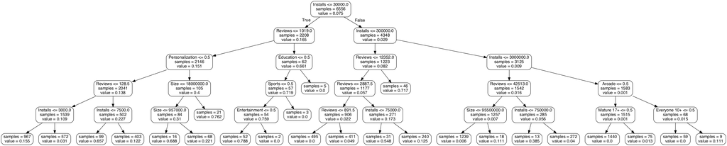

#### 4.4.5 Random Forest for Pricing (Free VS Paid)

```python
# build and fit the random forest model
model_forest = RandomForestClassifier(n_estimators = 100)
model_forest.fit(X_train, y_train)
# predict the probability that an app is free
model_forest.score(X_test, y_test)
```

```
0.9408536585365853
```

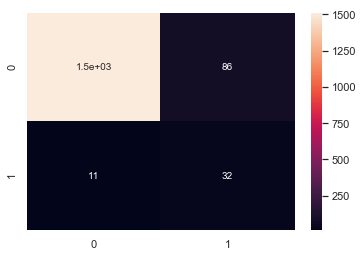

```python
# build confusion metrix for predicted y values
y_predicted = model_forest.predict(X_test)
cm = confusion_matrix(y_predicted, y_test)
sns.heatmap(cm, annot = True)
```

```python
# calculate the true positive rate for prediction
TPR=cm[0][0]/(cm[0][0]+cm[0][1])
round(TPR, 4)
```

```
0.9461
```

#### 4.4.6 Linear Regression for Pricing

```python
# select the paid app to analyze the pricing
cols=['Rating', 'Reviews', 'Size', 'Installs', 'Content Rating', 'Pri_Genres']
cat_cols=['Content Rating', 'Pri_Genres']
app_paid=app[app['Type']=='Paid']
```

```python
X1 = pd.get_dummies(app_paid[cols], columns=cat_cols, prefix='', prefix_sep='', drop_first=True)
X1 = sm.add_constant(X1)
y1 = app_paid['Price']
pd.concat([X1, y1], axis=1).head()
X1_train, X1_test, y1_train, y1_test = train_test_split(X1, y1, test_size=0.2, random_state=1234)
```

```python
# calculate the baseline accuracy for testing data
baseline_preds = y1_test.mean()
baseline_RMSE = np.mean(y1_test.apply(lambda x: abs(baseline_preds-x)))
print('Average baseline error for linear regression : ', round(baseline_RMSE, 2))
```

```
Average baseline error for linear regression :  19.86
```

```python
# Fit linear regression model and report results
linear = sm.OLS(y1_train, X1_train).fit()
linear.summary()
```

OLS Regression Results

| Dep. Variable: | Price | R-squared: | 0.363 |
| --- | --- | --- | --- |
| Model: | OLS | Adj. R-squared: | 0.295 |
| Method: | Least Squares | F-statistic: | 5.395 |
| Date: | Mon, 13 May 2019 | Prob (F-statistic): | 4.17e-22 |
| Time: | 18:53:12 | Log-Likelihood: | -2556.7 |
| No. Observations: | 483 | AIC: | 5207. |
| Df Residuals: | 436 | BIC: | 5404. |
| Df Model: | 46 |  |  |
| Covariance Type: | nonrobust |  |  |

|  | coef | std err | t | P>\|t\| | [0.025 | 0.975] |
| --- | --- | --- | --- | --- | --- | --- |
| const | 39.7185 | 24.389 | 1.629 | 0.104 | -8.215 | 87.652 |
| Rating | -8.1930 | 4.786 | -1.712 | 0.088 | -17.600 | 1.214 |
| Reviews | 3.446e-05 | 8.13e-05 | 0.424 | 0.672 | -0.000 | 0.000 |
| Size | 4.432e-08 | 1.21e-07 | 0.365 | 0.715 | -1.94e-07 | 2.83e-07 |
| Installs | -7.325e-06 | 1.84e-05 | -0.398 | 0.691 | -4.35e-05 | 2.89e-05 |
| Everyone 10+ | -0.1525 | 12.376 | -0.012 | 0.990 | -24.477 | 24.172 |
| Mature 17+ | -19.2583 | 17.757 | -1.085 | 0.279 | -54.158 | 15.641 |
| Teen | 0.3665 | 11.581 | 0.032 | 0.975 | -22.395 | 23.128 |
| Adventure | 0.1647 | 20.002 | 0.008 | 0.993 | -39.148 | 39.478 |
| Arcade | -2.4264 | 17.585 | -0.138 | 0.890 | -36.988 | 32.135 |
| Art & Design | 0.6289 | 38.609 | 0.016 | 0.987 | -75.253 | 76.511 |
| Auto & Vehicles | 0.1827 | 52.680 | 0.003 | 0.997 | -103.356 | 103.721 |
| Board | -1.6746 | 18.740 | -0.089 | 0.929 | -38.506 | 35.157 |
| Books & Reference | -0.9438 | 23.628 | -0.040 | 0.968 | -47.383 | 45.496 |
| Business | 0.4385 | 21.865 | 0.020 | 0.984 | -42.536 | 43.413 |
| Card | -2.5430 | 24.493 | -0.104 | 0.917 | -50.682 | 45.596 |
| Casino | 11.3944 | 52.418 | 0.217 | 0.828 | -91.629 | 114.417 |
| Casual | -1.7096 | 18.716 | -0.091 | 0.927 | -38.494 | 35.075 |
| Communication | -3.0108 | 18.929 | -0.159 | 0.874 | -40.215 | 34.193 |
| Dating | 7.2388 | 33.879 | 0.214 | 0.831 | -59.347 | 73.824 |
| Education | 2.0289 | 16.252 | 0.125 | 0.901 | -29.912 | 33.970 |
| Educational | -3.8589 | 23.593 | -0.164 | 0.870 | -50.230 | 42.512 |
| Entertainment | 132.9796 | 21.523 | 6.179 | 0.000 | 90.678 | 175.281 |
| Finance | 178.9603 | 19.572 | 9.144 | 0.000 | 140.493 | 217.427 |
| Food & Drink | 0.2711 | 38.547 | 0.007 | 0.994 | -75.490 | 76.032 |
| Health & Fitness | -0.1059 | 24.994 | -0.004 | 0.997 | -49.230 | 49.018 |
| Lifestyle | 73.9921 | 18.751 | 3.946 | 0.000 | 37.139 | 110.845 |
| Maps & Navigation | -3.2153 | 28.924 | -0.111 | 0.912 | -60.063 | 53.633 |
| Medical | 4.3362 | 15.297 | 0.283 | 0.777 | -25.729 | 34.401 |
| Music | -0.9608 | 38.181 | -0.025 | 0.980 | -76.003 | 74.081 |
| News & Magazines | 10.5831 | 38.887 | 0.272 | 0.786 | -65.845 | 87.012 |
| Parenting | 3.4893 | 52.637 | 0.066 | 0.947 | -99.965 | 106.944 |
| Personalization | -2.1525 | 15.582 | -0.138 | 0.890 | -32.777 | 28.472 |
| Photography | -0.8787 | 19.797 | -0.044 | 0.965 | -39.788 | 38.030 |
| Productivity | -1.1767 | 19.703 | -0.060 | 0.952 | -39.902 | 37.549 |
| Puzzle | -1.1760 | 18.376 | -0.064 | 0.949 | -37.292 | 34.940 |
| Racing | -3.2168 | 31.951 | -0.101 | 0.920 | -66.013 | 59.580 |
| Role Playing | 2.6002 | 16.784 | 0.155 | 0.877 | -30.387 | 35.588 |
| Shopping | 1.9783 | 52.715 | 0.038 | 0.970 | -101.629 | 105.586 |
| Simulation | -2.0321 | 20.202 | -0.101 | 0.920 | -41.738 | 37.674 |
| Social | -8.6383 | 38.552 | -0.224 | 0.823 | -84.408 | 67.132 |
| Sports | -2.2970 | 17.553 | -0.131 | 0.896 | -36.797 | 32.202 |
| Strategy | 1.7560 | 21.638 | 0.081 | 0.935 | -40.771 | 44.283 |
| Tools | -2.4380 | 15.732 | -0.155 | 0.877 | -33.359 | 28.483 |
| Travel & Local | -2.2360 | 24.772 | -0.090 | 0.928 | -50.923 | 46.451 |
| Video Players & Editors | -3.5197 | 29.050 | -0.121 | 0.904 | -60.615 | 53.575 |
| Weather | 0.1838 | 24.955 | 0.007 | 0.994 | -48.863 | 49.230 |

| Omnibus: | 293.077 | Durbin-Watson: | 2.105 |
| --- | --- | --- | --- |
| Prob(Omnibus): | 0.000 | Jarque-Bera (JB): | 7079.197 |
| Skew: | 2.157 | Prob(JB): | 0.00 |
| Kurtosis: | 21.252 | Cond. No. | 1.10e+09 |

Warnings:  
[1] Standard Errors assume that the covariance matrix of the errors is correctly specified.  
[2] The condition number is large, 1.1e+09. This might indicate that there are  
strong multicollinearity or other numerical problems.

```python
# Predict price for test set, compare to actual price
y_pred = linear.predict(X1_test)
RMSE_lr = np.sqrt(mean_squared_error(y1_test,y_pred))

print('RMSE of linear Regression for Pricing: ', round(RMSE_lr,2))
```

```
RMSE of linear Regression for Pricing:  52.61
```

#### 4.4.7 Findings from Pricing

After comparing our four models built for pricing, we have the following findings:

Although Random forest gives us a higher accuracy rate than baseline, **we still need to reflect on whether prediction payment is an important finding**, in the situation that over 90% of apps are free. For now, the value of the forecast is modest. Based on the modeling of this dataset, we can only recommend developers to launch a free download app in most cases.

As app users, we think **"free download or not" can no longer well reflect an app pricing strategy.** Through investigation, we find that **a large number of apps are now profitable by providing other paid features after downloading**. This Pricing strategy is called Freemium Pricing Model. Unfortunately, our dataset does not contain any variable that evaluates whether an app has additional paid items, which makes the information about price or pricing strategy extremely incomplete, also affects our prediction of price. We suggest that the Google App Store add this information to reflect better the "price" of the App, which is also very meaningful for consumers.

## 5. Suggestions

Suggestion and Summary: We put together all the ideas and findings mentioned in the previous sections (basically Feature Engineering and Modeling) here, and the relevant supports can be found in the previous content.

**To achieve higher Rating:**

- Try to get as many as possible user reviews, both positive or negative reviews are very meaningful to improve Rating in the long run.
- Fix bugs in time and update the app frequently and effectively. App updates every six months can beat at least three-quarters of apps.
- The size of apps varies significantly according to the content, so we suggest that it should be designed as small as possible.

**Findings from Pricing:**

- We can predict whether apps should be free through the models we built.
- The dataset lack information about which most apps have the features that users can choose to pay for after free download. This constraints our ability to predicting precise price should a paid app set.

**Suggestions from Review:**

- Increase the number and length of user comments (provide some optional keywords in the comments section).
- Loading time, convenience, and pricing are highly mentioned by users, which indicates that the developers may want to consider these three aspects during designing mainly.
- Adjust the time and length of the ads.

#### Suggestion for Google app store:

- 10-scale rating will be better for app differentiation.
- Add measurement about whether there is payment in the app after free download could better reflect the pricing strategy of an app.